# 20231016_missModResults

### 10% Todd

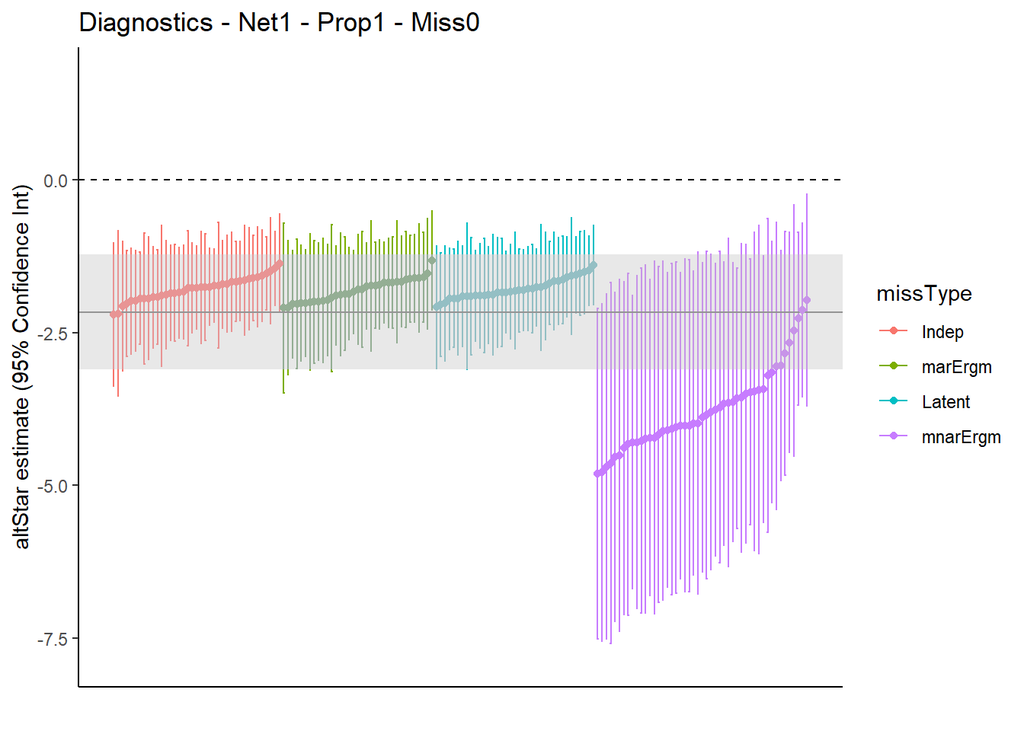

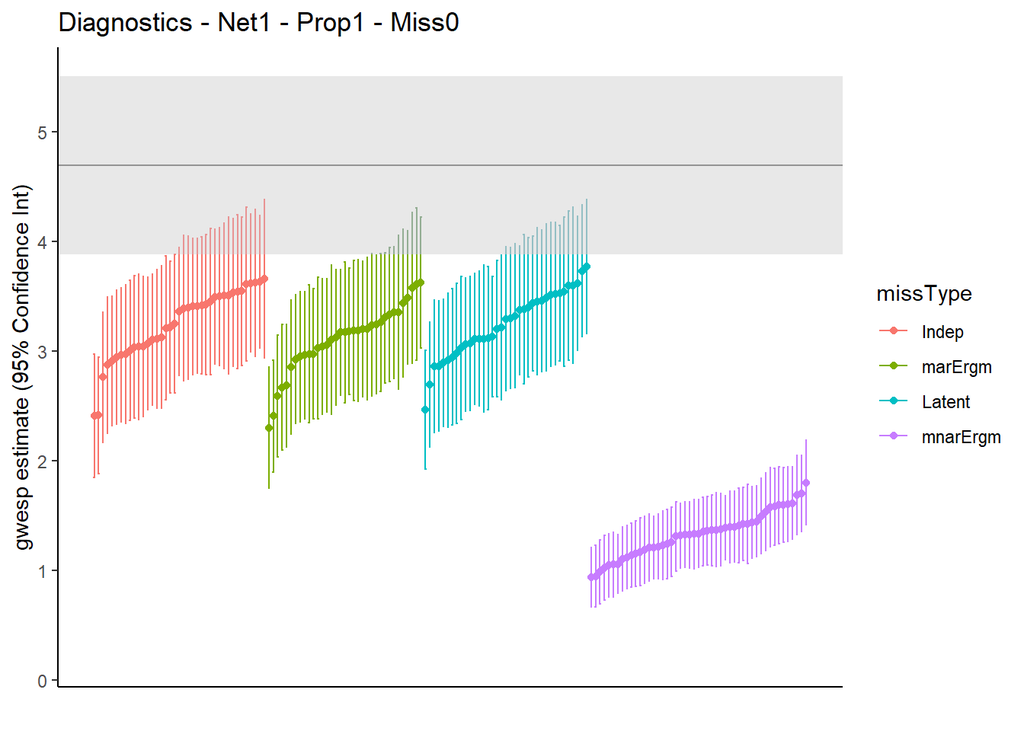

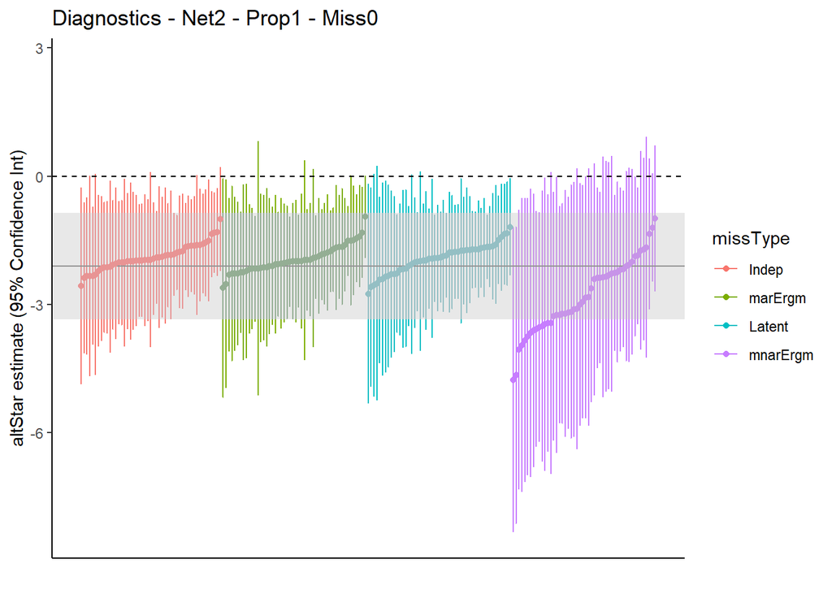

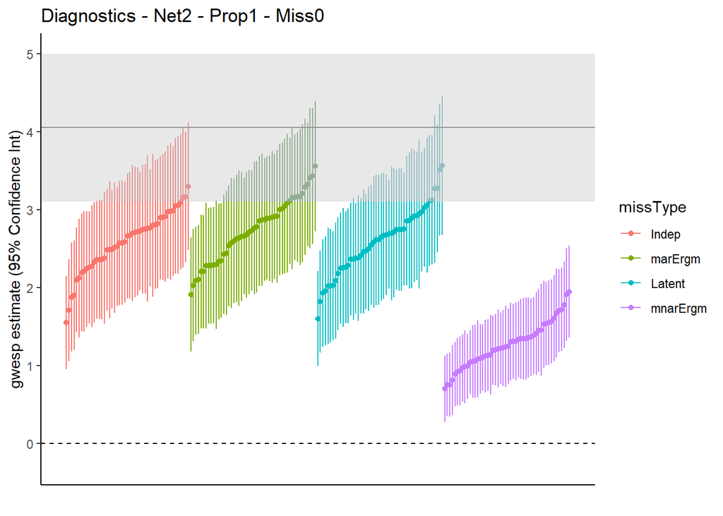

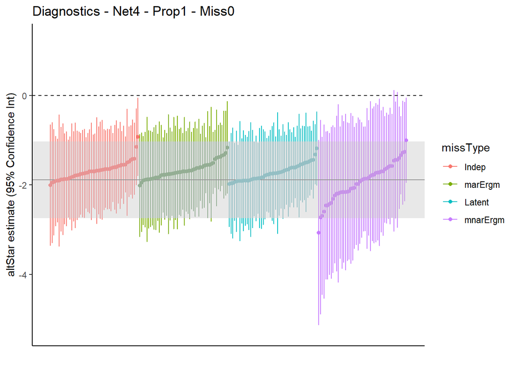

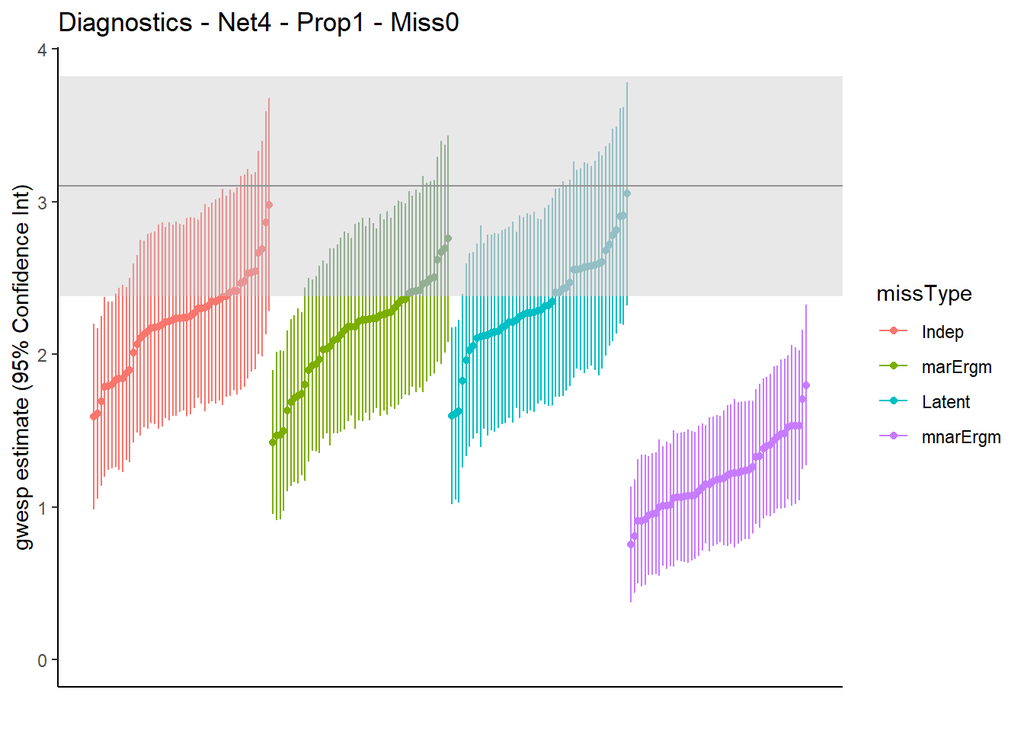

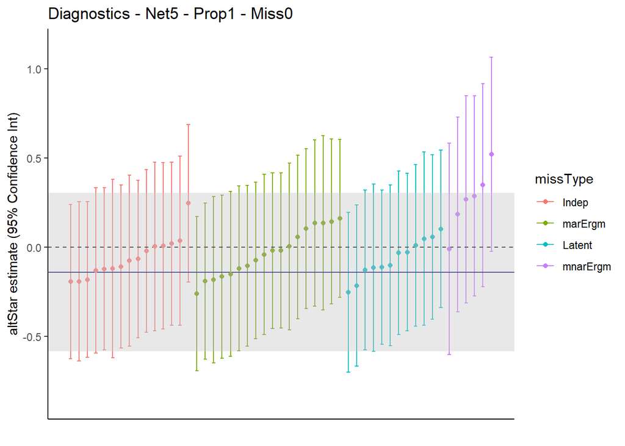

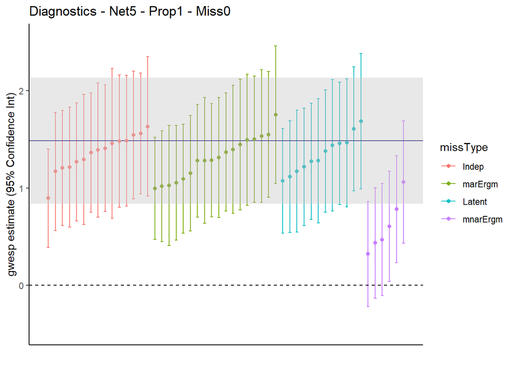

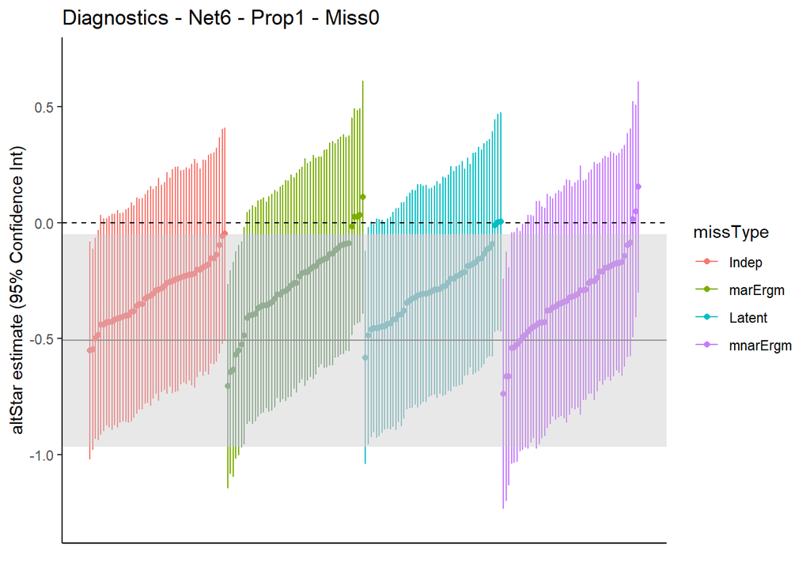

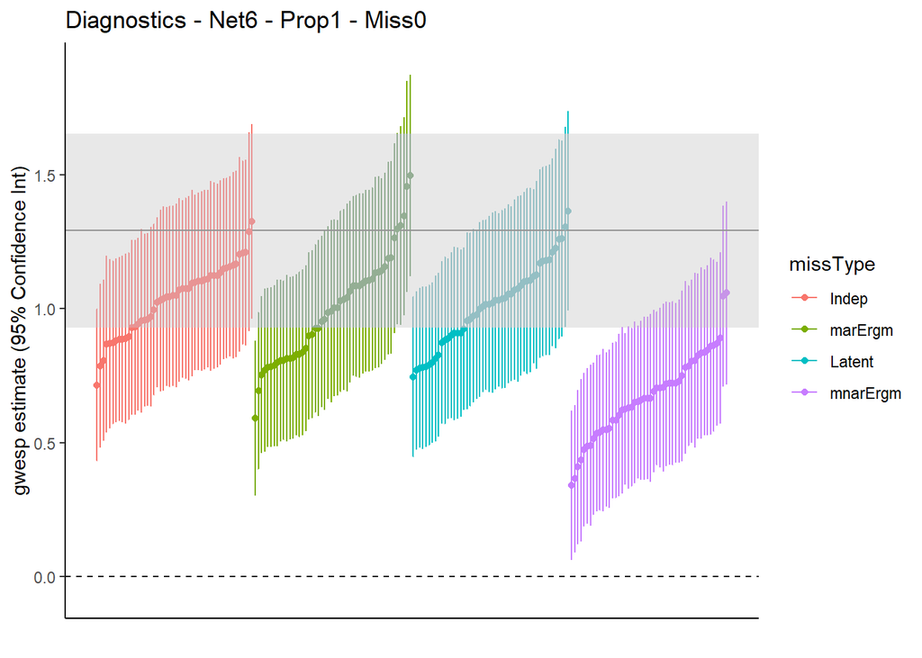

```r
# loading in the output results
outputList = list.files(here("Output", "20230825_simMissReest", "Todd"))

# applying the code above to different reestimations
# TODO: specify the missingness saved for current chunk, 1 = "NA"/peter, 2 = "0"/Todd
chunkMissSave = 2

# TODO: specify the chosen missingness proportion for each chunk (1/3 or 3.5/6)
chunkMissProp = 1

# take out the index for the chosen missingness saved value
chosenMissLabel = missSaveLabel[chunkMissSave]
chosenMissValue = missSaveValue[chunkMissSave]


# now looping with a specific vector of applicable networks
# TODO: specify the UCINet networks for the chunk, these are networks with enough re-estimations
chunkNetworks = c(1, 2, 4, 5, 6)

# TODO: vector of file names for regex
chunkRdataNames = c("20231005_missNetReest_net",
                    "20231005_missNetReest_net",
                    "20231005_missNetReest_net",
                    "20231005_missNetReest_net",
                    "20231012_missNetReest_net")

chunkMnarNames = c("20231012_missErgmNetReest_Miss",
                   "20231012_missErgmNetReest_Miss",
                   "20231012_missErgmNetReest_Miss",
                   "20231012_missErgmNetReest_Miss",
                   "20231012_missErgmNetReest_Miss")

# loop for all specified networks
for(chunkInd in 1:length(chunkNetworks)){

  # make sure the re-estimation lists are empty in the beginning
  modelResList = list()
  modelSeList = list()
  missModelList = list()
  propMissList = list()

  # set a specific index for the network
  chosenNetInd = chunkNetworks[chunkInd]

  # file list for the chosen network index
  chosenNetOutFiles = grep(paste(chunkRdataNames[chunkInd], chosenNetInd, sep =""), outputList)

  ## regex the MNAR files
  chosenMnarOutFiles = grep(paste(chunkMnarNames[chunkInd], chosenMissLabel, "_net", chosenNetInd, sep = ""), outputList)

  # combine the two indices
  combinedNetOutList = c(chosenNetOutFiles, chosenMnarOutFiles)

  # check to make sure there aren't any duplicates
  if( length(unique(combinedNetOutList)) != length(combinedNetOutList)){
    stop("Duplicate re-estimation datafiles! BAD.")
  }

  # loop to load
  chosenNetOutList = outputList[combinedNetOutList]

  for(fileInd in 1:length(chosenNetOutList)){
    # load all files
    load(here("Output", "20230825_simMissReest", chosenMissLabel, chosenNetOutList[fileInd]))

    # suppress these version difference warnings.
    suppressWarnings({
    modelResList[[fileInd]] = modelres$coefficients
    modelSeList[[fileInd]] = summary(modelres)$coefficients[,2]

    })

    # slight difference for the chosenMnarOutFiles because missModelList[[fileInd]] = always 4 (let 2 be mar ergm, 4 be mnar ergm)

    # this branch *should* be setting the miss model to 4 if they were regexed to be a part of the mnar list.
    if(combinedNetOutList[fileInd] %in% chosenMnarOutFiles){
     missModelList[[fileInd]] = 4
    } else {
     missModelList[[fileInd]] = as.integer(sub(".*?_missModel.*?(\\d+).*", "\\1", chosenNetOutList[[fileInd]]))
    }

    # propmiss should be the same
    propMissList[[fileInd]] = as.integer(sub(".*?_prop.*?(\\d+).*", "\\1", chosenNetOutList[[fileInd]]))
  }

  # first try with alt star
  chosenPara = 2

  tempTruePara = trueCoefList[[chosenNetInd]][chosenPara]
  tempTrueSe = trueSeList[[chosenNetInd]][chosenPara]


  # test run of the plot function
  testPlotData = prepMissPlot(modelResList = modelResList,
                              modelSeList = modelSeList,
                              missModelList = missModelList,
                              propMissList = propMissList,
                              chosenProp = chunkMissProp,
                              chosenPara = "altStar")

  head(testPlotData)


  # and see if the plot here matches the one above
  missCaterpillarPlot(plotData = testPlotData,
                      truePara = tempTruePara,
                      trueSe = tempTrueSe,
                      chosenPara = "altStar",
                      chosenNetInd = chosenNetInd,
                      chosenProp = chunkMissProp,
                      chosenMiss = chosenMissValue) %>%
    print()




  # still need to take out true parameter values
  chosenPara = 3

  tempTruePara = trueCoefList[[chosenNetInd]][chosenPara]
  tempTrueSe = trueSeList[[chosenNetInd]][chosenPara]


  # test run of the plot function
  testPlotData = prepMissPlot(modelResList = modelResList,
                              modelSeList = modelSeList,
                              missModelList = missModelList,
                              propMissList = propMissList,
                              chosenProp = chunkMissProp,
                              chosenPara = "gwesp")

  head(testPlotData)


  # and see if the plot here matches the one above
  missCaterpillarPlot(plotData = testPlotData,
                      truePara = tempTruePara,
                      trueSe = tempTrueSe,
                      chosenPara = "gwesp",
                      chosenNetInd = chosenNetInd,
                      chosenProp = chunkMissProp,
                      chosenMiss = chosenMissValue) %>%
    print()

  # a temporary data frame from the output to be binded to the big data frame
  tempFailData = prepFailPlot(propMissList = propMissList,
                              missModelList = missModelList,
                              chosenNetInd = chosenNetInd,
                              chosenProp = chunkMissProp,
                              chosenMiss = chosenMissValue)

  # and bind it
  failRateData = rbind(failRateData, tempFailData)

}
```

### 35% Todd

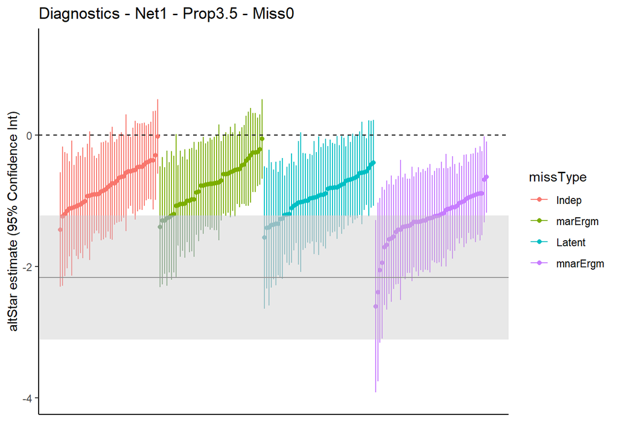

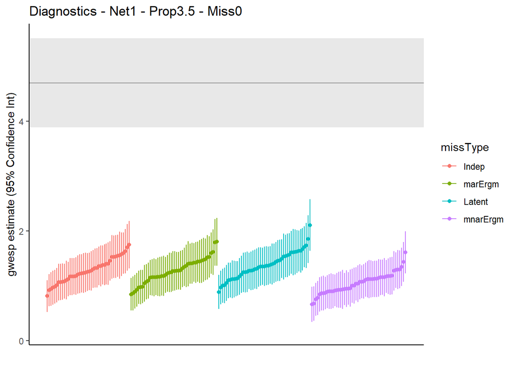

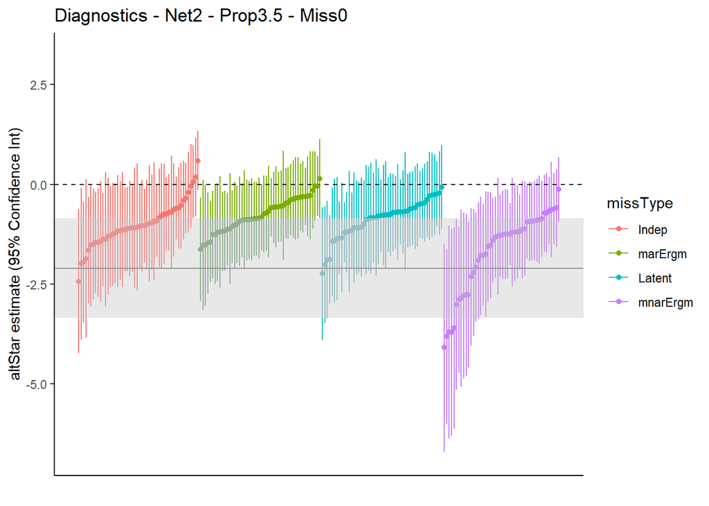

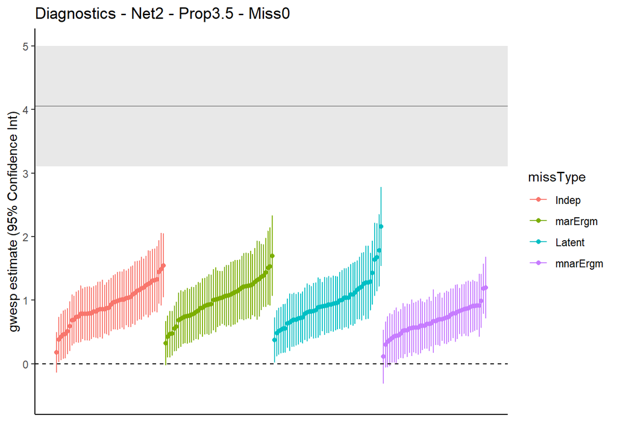

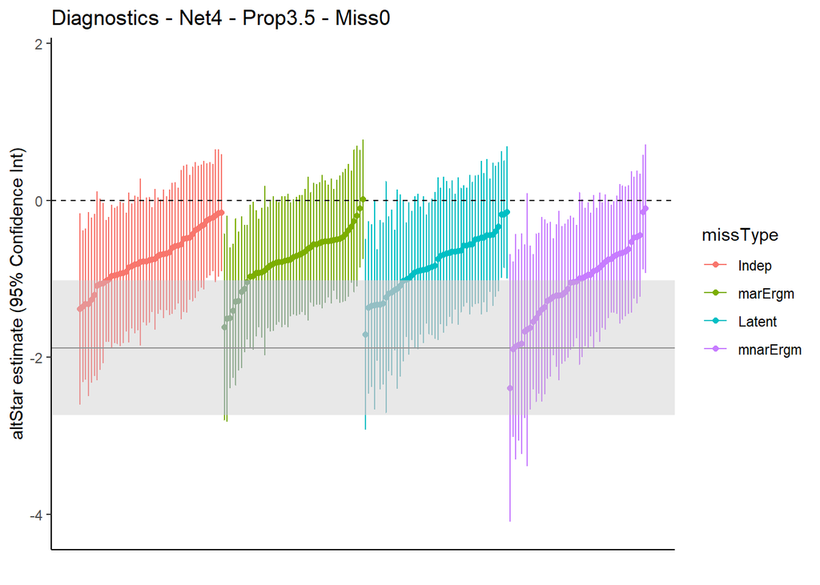

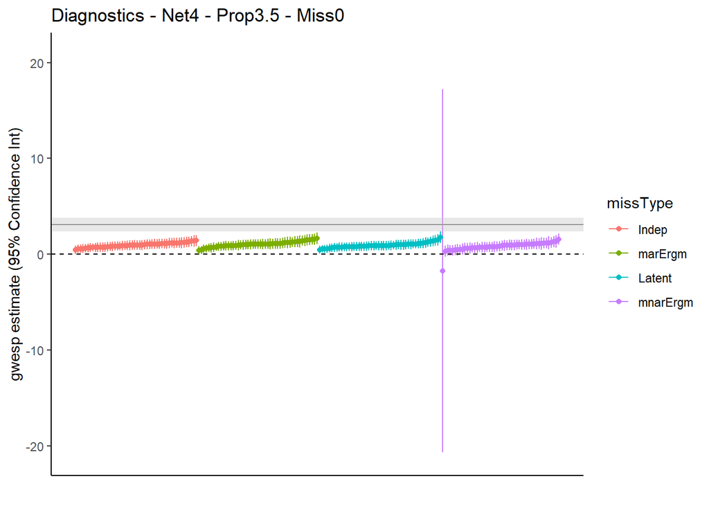

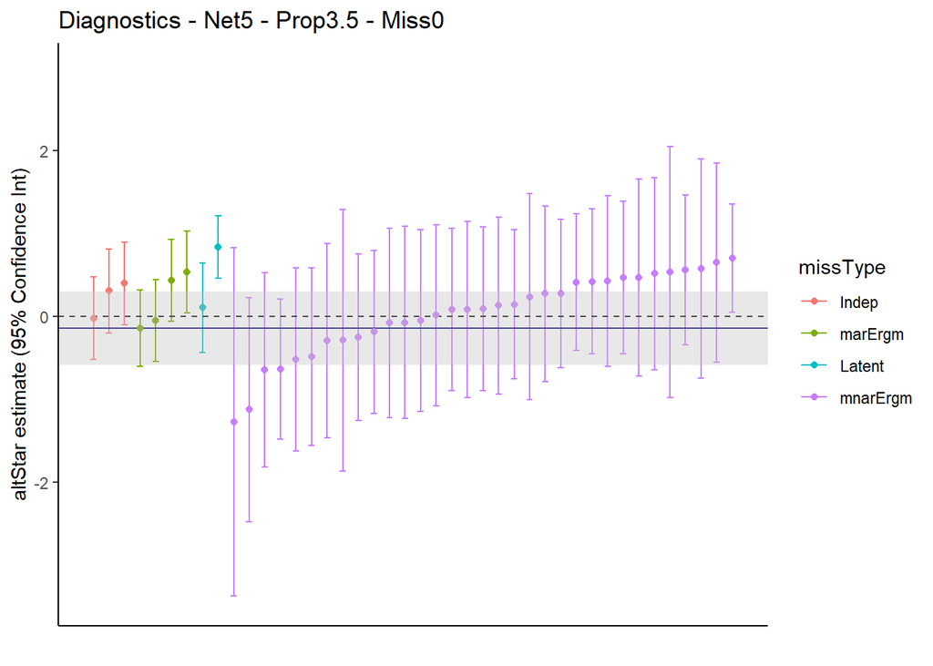

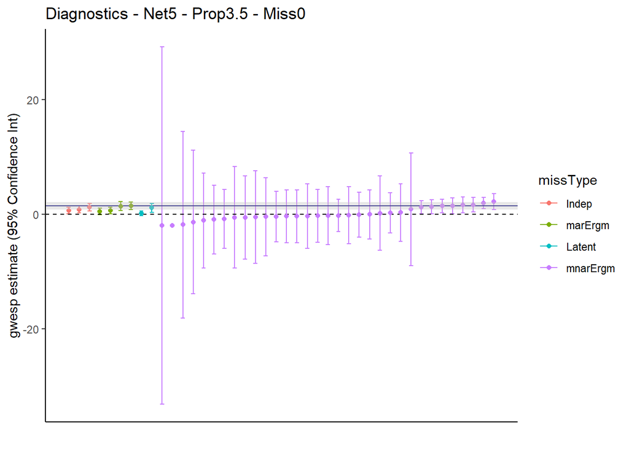

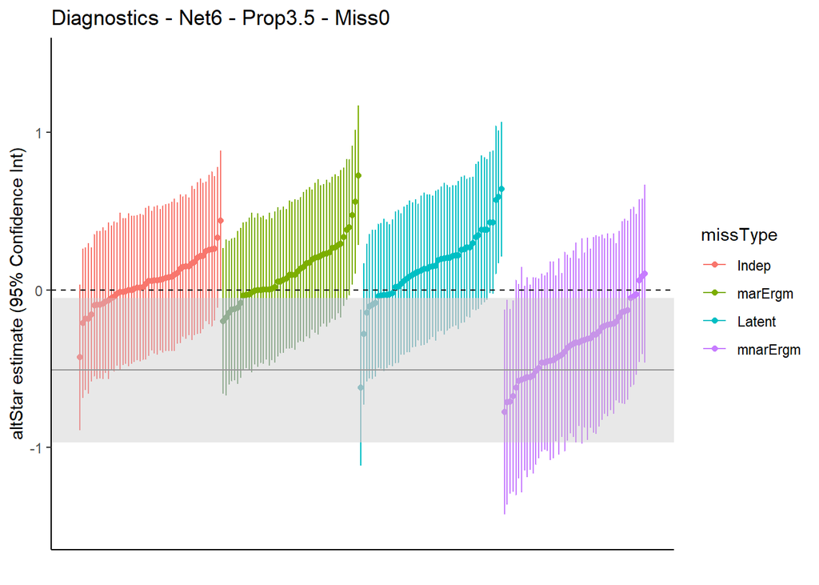

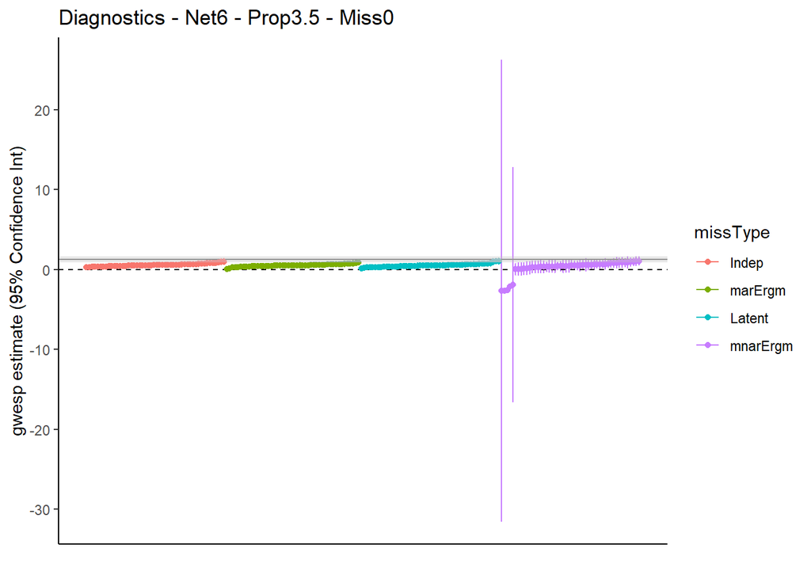

```r
# loading in the output results
outputList = list.files(here("Output", "20230825_simMissReest", "Todd"))

# applying the code above to different reestimations
# TODO: specify the missingness saved for current chunk, 1 = "NA"/peter, 2 = "0"/Todd
chunkMissSave = 2

# TODO: specify the chosen missingness proportion for each chunk (1/3 or 3.5/6)
chunkMissProp = 3
chunkMissPropFloat = 3.5 # specifically for 35% missingness because I regex by taking the first number next to 'prop'.

# take out the index for the chosen missingness saved value
chosenMissLabel = missSaveLabel[chunkMissSave]
chosenMissValue = missSaveValue[chunkMissSave]


# now looping with a specific vector of applicable networks
# TODO: specify the UCINet networks for the chunk, these are networks with enough re-estimations
chunkNetworks = c(1, 2, 4, 5, 6)

# TODO: vector of file names for regex
chunkRdataNames = c("20231005_missNetReest_net",
                    "20231005_missNetReest_net",
                    "20231005_missNetReest_net",
                    "20231012_missNetReest_net",
                    "20231012_missNetReest_net")

chunkMnarNames = c("20231012_missErgmNetReest_Miss",
                   "20231012_missErgmNetReest_Miss",
                   "20231012_missErgmNetReest_Miss",
                   "20231012_missErgmNetReest_Miss",
                   "20231012_missErgmNetReest_Miss")

# loop for all specified networks
for(chunkInd in 1:length(chunkNetworks)){

  # make sure the re-estimation lists are empty in the beginning
  modelResList = list()
  modelSeList = list()
  missModelList = list()
  propMissList = list()

  # set a specific index for the network
  chosenNetInd = chunkNetworks[chunkInd]

  # file list for the chosen network index
  chosenNetOutFiles = grep(paste(chunkRdataNames[chunkInd], chosenNetInd, sep =""), outputList)

  ## regex the MNAR files
  chosenMnarOutFiles = grep(paste(chunkMnarNames[chunkInd], chosenMissLabel, "_net", chosenNetInd, sep = ""), outputList)

  # combine the two indices
  combinedNetOutList = c(chosenNetOutFiles, chosenMnarOutFiles)

  # check to make sure there aren't any duplicates
  if( length(unique(combinedNetOutList)) != length(combinedNetOutList)){
    stop("Duplicate re-estimation datafiles! BAD.")
  }

  # loop to load
  chosenNetOutList = outputList[combinedNetOutList]

  for(fileInd in 1:length(chosenNetOutList)){
    # load all files
    load(here("Output", "20230825_simMissReest", chosenMissLabel, chosenNetOutList[fileInd]))

    # suppress these version difference warnings.
    suppressWarnings({
    modelResList[[fileInd]] = modelres$coefficients
    modelSeList[[fileInd]] = summary(modelres)$coefficients[,2]

    })

    # slight difference for the chosenMnarOutFiles because missModelList[[fileInd]] = always 4 (let 2 be mar ergm, 4 be mnar ergm)

    # this branch *should* be setting the miss model to 4 if they were regexed to be a part of the mnar list.
    if(combinedNetOutList[fileInd] %in% chosenMnarOutFiles){
     missModelList[[fileInd]] = 4
    } else {
     missModelList[[fileInd]] = as.integer(sub(".*?_missModel.*?(\\d+).*", "\\1", chosenNetOutList[[fileInd]]))
    }

    # propmiss should be the same
    propMissList[[fileInd]] = as.integer(sub(".*?_prop.*?(\\d+).*", "\\1", chosenNetOutList[[fileInd]]))
  }

  # first try with alt star
  chosenPara = 2

  tempTruePara = trueCoefList[[chosenNetInd]][chosenPara]
  tempTrueSe = trueSeList[[chosenNetInd]][chosenPara]


  # test run of the plot function
  testPlotData = prepMissPlot(modelResList = modelResList,
                              modelSeList = modelSeList,
                              missModelList = missModelList,
                              propMissList = propMissList,
                              chosenProp = chunkMissProp,
                              chosenPara = "altStar")

  head(testPlotData)


  # and see if the plot here matches the one above
  missCaterpillarPlot(plotData = testPlotData,
                      truePara = tempTruePara,
                      trueSe = tempTrueSe,
                      chosenPara = "altStar",
                      chosenNetInd = chosenNetInd,
                      chosenProp = chunkMissPropFloat,
                      chosenMiss = chosenMissValue) %>%
    print()

  # still need to take out true parameter values
  chosenPara = 3

  tempTruePara = trueCoefList[[chosenNetInd]][chosenPara]
  tempTrueSe = trueSeList[[chosenNetInd]][chosenPara]


  # test run of the plot function
  testPlotData = prepMissPlot(modelResList = modelResList,
                              modelSeList = modelSeList,
                              missModelList = missModelList,
                              propMissList = propMissList,
                              chosenProp = chunkMissProp,
                              chosenPara = "gwesp")

  head(testPlotData)


  # and see if the plot here matches the one above
  missCaterpillarPlot(plotData = testPlotData,
                      truePara = tempTruePara,
                      trueSe = tempTrueSe,
                      chosenPara = "gwesp",
                      chosenNetInd = chosenNetInd,
                      chosenProp = chunkMissPropFloat,
                      chosenMiss = chosenMissValue) %>%
    print()

  # a temporary data frame from the output to be binded to the big data frame
  tempFailData = prepFailPlot(propMissList = propMissList,
                              missModelList = missModelList,
                              chosenNetInd = chosenNetInd,
                              chosenProp = chunkMissProp,
                              chosenMiss = chosenMissValue)

  # and bind it
  failRateData = rbind(failRateData, tempFailData)

}
```

### 60% Todd

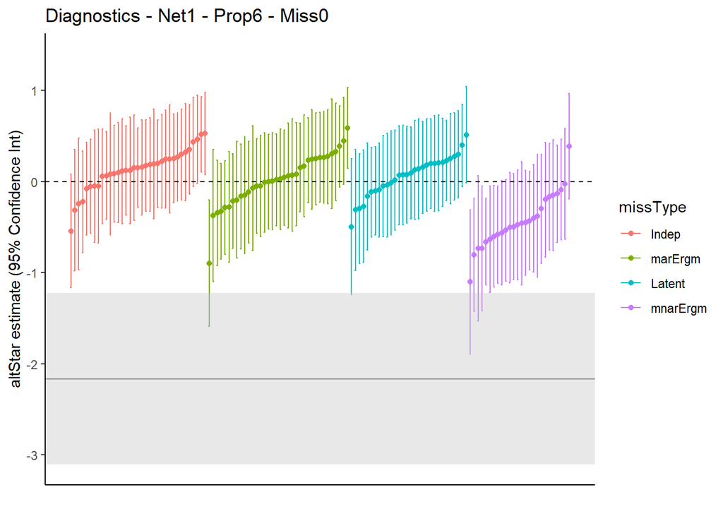

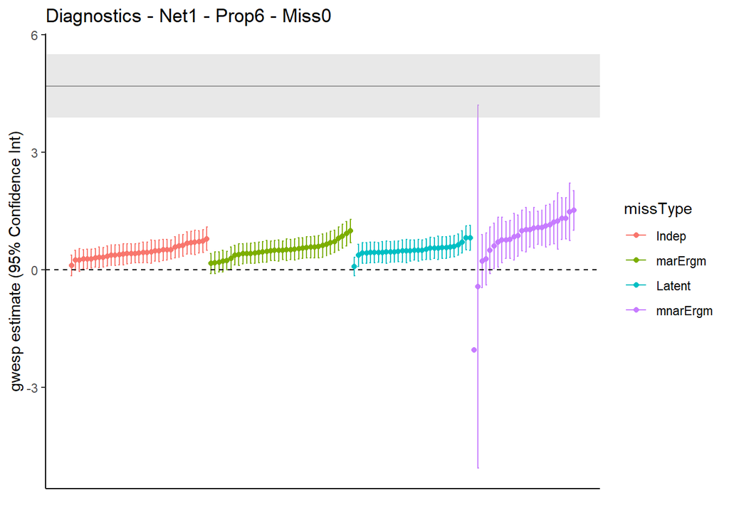

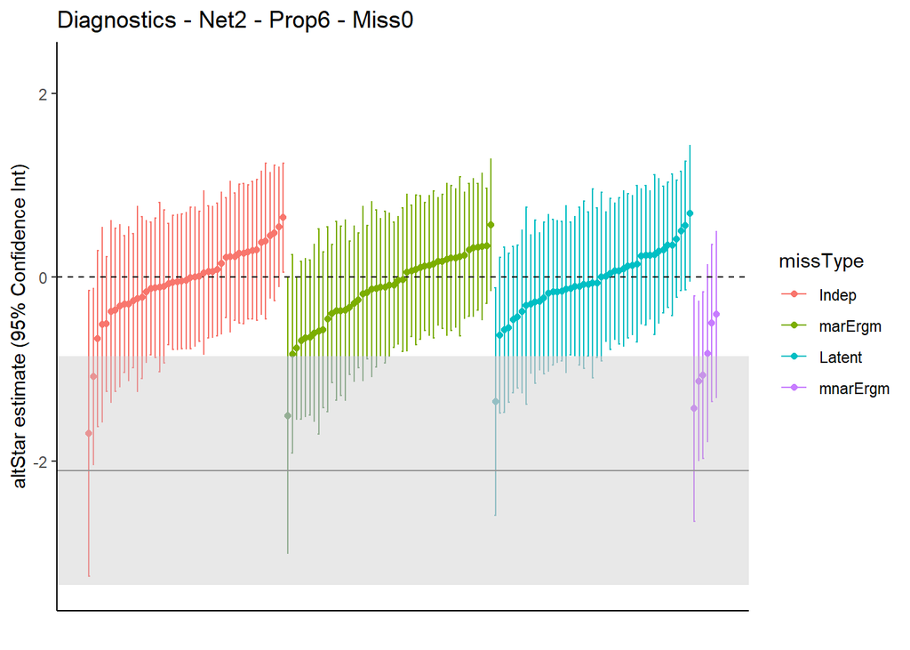

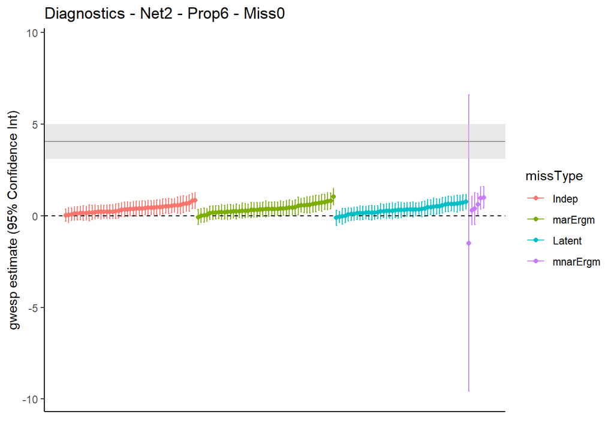

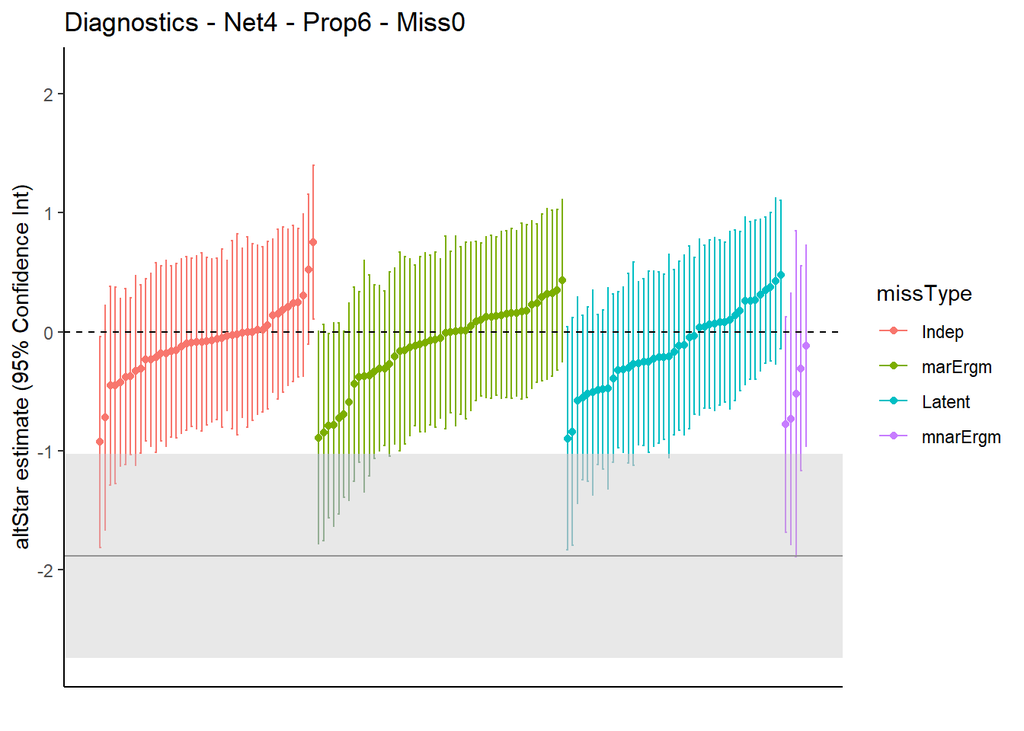

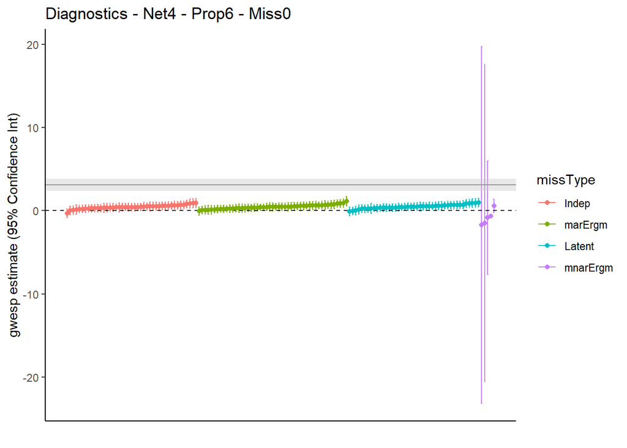

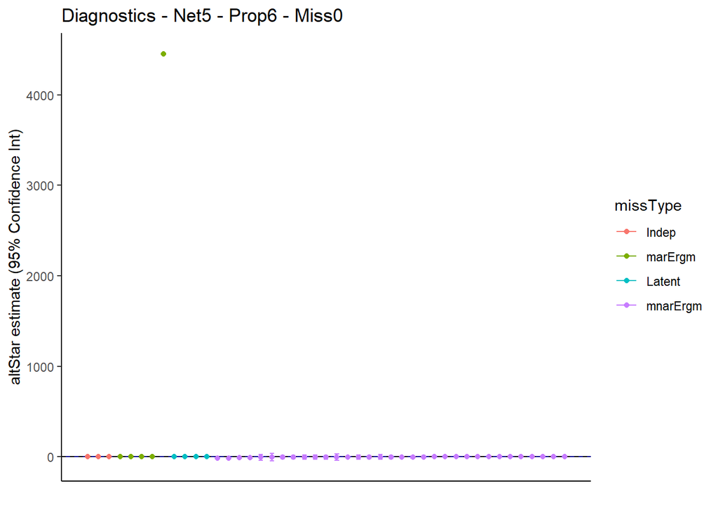

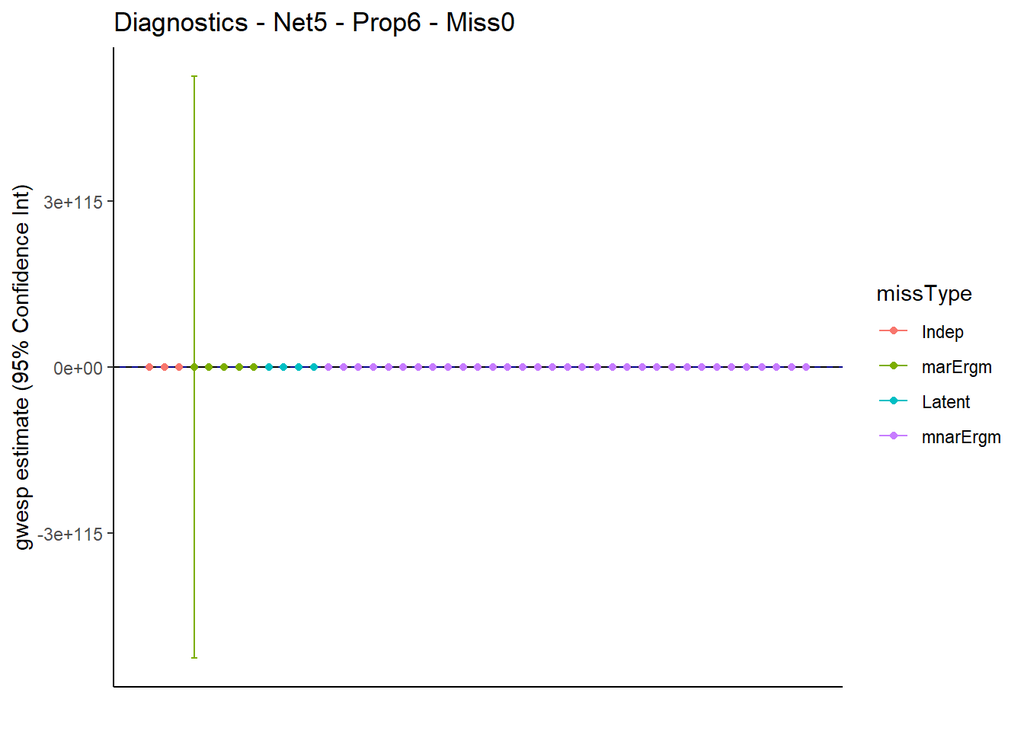

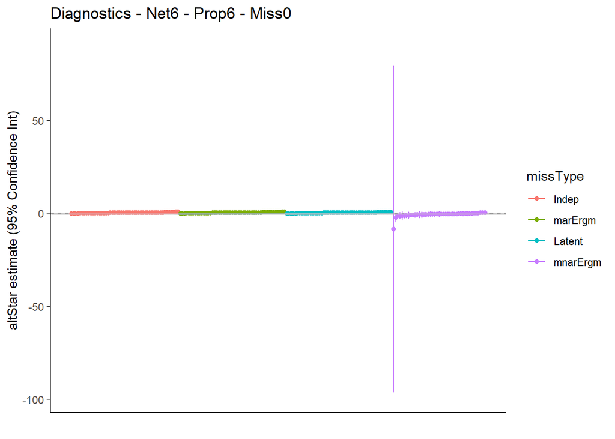

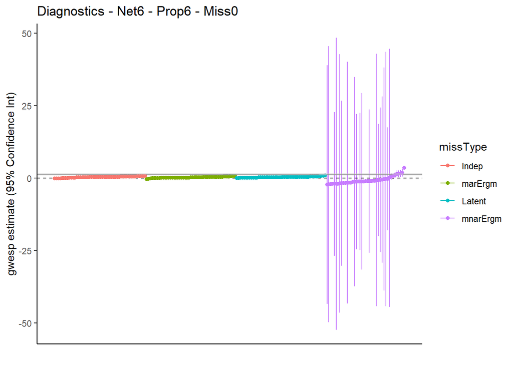

```r
# loading in the output results
outputList = list.files(here("Output", "20230825_simMissReest", "Todd"))

# applying the code above to different reestimations
# TODO: specify the missingness saved for current chunk, 1 = "NA"/peter, 2 = "0"/Todd
chunkMissSave = 2

# TODO: specify the chosen missingness proportion for each chunk (1/3 or 3.5/6)
chunkMissProp = 6

# take out the index for the chosen missingness saved value
chosenMissLabel = missSaveLabel[chunkMissSave]
chosenMissValue = missSaveValue[chunkMissSave]


# now looping with a specific vector of applicable networks
# TODO: specify the UCINet networks for the chunk, these are networks with enough re-estimations
chunkNetworks = c(1, 2, 4, 5, 6)

# TODO: vector of file names for regex
chunkRdataNames = c("20231006_missNetReest_net",
                    "20231006_missNetReest_net",
                    "20231006_missNetReest_net",
                    "20231011_missNetReest_net",
                    "20231011_missNetReest_net")

chunkMnarNames = c("20231012_missErgmNetReest_Miss",
                   "20231012_missErgmNetReest_Miss",
                   "20231012_missErgmNetReest_Miss",
                   "20231012_missErgmNetReest_Miss",
                   "20231012_missErgmNetReest_Miss")

# loop for all specified networks
for(chunkInd in 1:length(chunkNetworks)){

  # make sure the re-estimation lists are empty in the beginning
  modelResList = list()
  modelSeList = list()
  missModelList = list()
  propMissList = list()

  # set a specific index for the network
  chosenNetInd = chunkNetworks[chunkInd]

  # file list for the chosen network index
  chosenNetOutFiles = grep(paste(chunkRdataNames[chunkInd], chosenNetInd, sep =""), outputList)

  ## regex the MNAR files
  chosenMnarOutFiles = grep(paste(chunkMnarNames[chunkInd], chosenMissLabel, "_net", chosenNetInd, sep = ""), outputList)

  # combine the two indices
  combinedNetOutList = c(chosenNetOutFiles, chosenMnarOutFiles)

  # check to make sure there aren't any duplicates
  if( length(unique(combinedNetOutList)) != length(combinedNetOutList)){
    stop("Duplicate re-estimation datafiles! BAD.")
  }

  # loop to load
  chosenNetOutList = outputList[combinedNetOutList]

  for(fileInd in 1:length(chosenNetOutList)){
    # load all files
    load(here("Output", "20230825_simMissReest", chosenMissLabel, chosenNetOutList[fileInd]))

    # suppress these version difference warnings.
    suppressWarnings({
    modelResList[[fileInd]] = modelres$coefficients
    modelSeList[[fileInd]] = summary(modelres)$coefficients[,2]

    })

    # slight difference for the chosenMnarOutFiles because missModelList[[fileInd]] = always 4 (let 2 be mar ergm, 4 be mnar ergm)

    # this branch *should* be setting the miss model to 4 if they were regexed to be a part of the mnar list.
    if(combinedNetOutList[fileInd] %in% chosenMnarOutFiles){
     missModelList[[fileInd]] = 4
    } else {
     missModelList[[fileInd]] = as.integer(sub(".*?_missModel.*?(\\d+).*", "\\1", chosenNetOutList[[fileInd]]))
    }

    # propmiss should be the same
  propMissList[[fileInd]] = as.integer(sub(".*?_prop.*?(\\d+).*", "\\1", chosenNetOutList[[fileInd]]))
}

# first try with alt star
chosenPara = 2

tempTruePara = trueCoefList[[chosenNetInd]][chosenPara]
tempTrueSe = trueSeList[[chosenNetInd]][chosenPara]


# test run of the plot function
testPlotData = prepMissPlot(modelResList = modelResList,
                            modelSeList = modelSeList,
                            missModelList = missModelList,
                            propMissList = propMissList,
                            chosenProp = chunkMissProp,
                            chosenPara = "altStar")

head(testPlotData)


# and see if the plot here matches the one above
missCaterpillarPlot(plotData = testPlotData,
                    truePara = tempTruePara,
                    trueSe = tempTrueSe,
                    chosenPara = "altStar",
                    chosenNetInd = chosenNetInd,
                    chosenProp = chunkMissProp,
                    chosenMiss = chosenMissValue) %>%
    print()


# still need to take out true parameter values
chosenPara = 3

tempTruePara = trueCoefList[[chosenNetInd]][chosenPara]
tempTrueSe = trueSeList[[chosenNetInd]][chosenPara]


# test run of the plot function
testPlotData = prepMissPlot(modelResList = modelResList,
                            modelSeList = modelSeList,
                            missModelList = missModelList,
                            propMissList = propMissList,
                            chosenProp = chunkMissProp,
                            chosenPara = "gwesp")

head(testPlotData)


# and see if the plot here matches the one above
missCaterpillarPlot(plotData = testPlotData,
                    truePara = tempTruePara,
                    trueSe = tempTrueSe,
                    chosenPara = "gwesp",
                    chosenNetInd = chosenNetInd,
                    chosenProp = chunkMissProp,
                    chosenMiss = chosenMissValue) %>%
    print()

# a temporary data frame from the output to be binded to the big data frame
tempFailData = prepFailPlot(propMissList = propMissList,
                            missModelList = missModelList,
                            chosenNetInd = chosenNetInd,
                            chosenProp = chunkMissProp,
                            chosenMiss = chosenMissValue)

# and bind it
failRateData = rbind(failRateData, tempFailData)

}
```

## Sparse plots

The plots below are specifically plots with very sparse amounts of successful re-estimations.

### 10% Peter

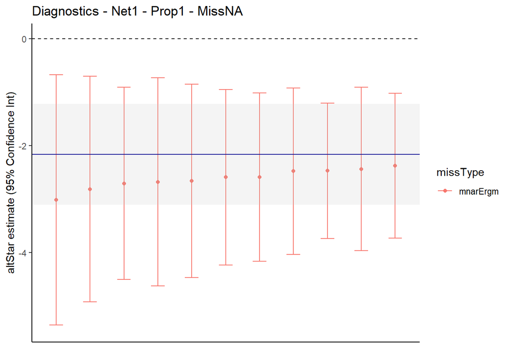

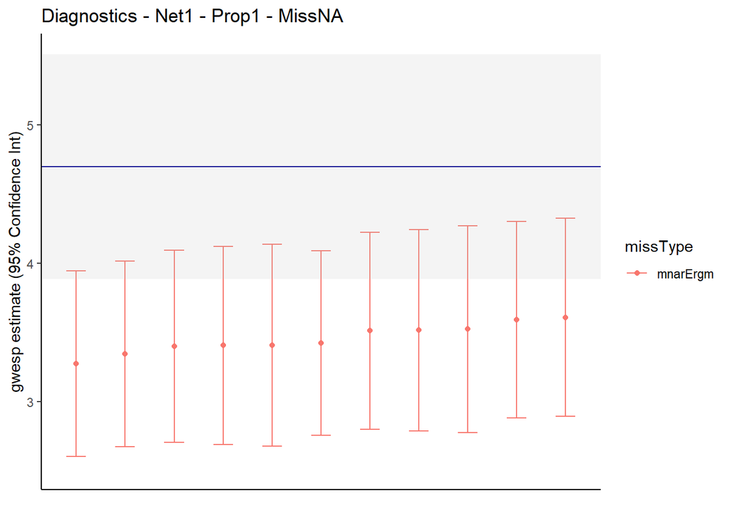

```r
# 10% missingness - Peter
# loading in the output results
outputList = list.files(here("Output", "20230825_simMissReest", "Peter"))

# applying the code above to different reestimations
# TODO: specify the missingness saved for current chunk, 1 = "NA"/peter, 2 = "0"/Todd
chunkMissSave = 1

# TODO: specify the chosen missingness proportion for each chunk (1/3 or 3.5/6)
chunkMissProp = 1

# take out the index for the chosen missingness saved value
chosenMissLabel = missSaveLabel[chunkMissSave]
chosenMissValue = missSaveValue[chunkMissSave]


# now looping with a specific vector of applicable networks
# TODO: specify the UCINet networks for the chunk, these are networks with enough re-estimations
chunkNetworks = c(1)

# note:
# net 3 is so messed up it has ONE converged estimation for this set
# 20231010_missNetReest_net3_missModel1_prop1_trial9.RData

# handle fail rates separately. these data structures are very unstandardised.

# TODO: vector of file names for regex
chunkRdataNames = c("20231005_missNetReest_net")

chunkMnarNames = c("20231011_missErgmNetReest_Miss")

# loop for all specified networks
for(chunkInd in 1:length(chunkNetworks)){

  # make sure the re-estimation lists are empty in the beginning
  modelResList = list()
  modelSeList = list()
  missModelList = list()
  propMissList = list()

  # set a specific index for the network
  chosenNetInd = chunkNetworks[chunkInd]

  # file list for the chosen network index
  chosenNetOutFiles = grep(paste(chunkRdataNames[chunkInd], chosenNetInd, sep =""), outputList)

  ## regex the MNAR files
  chosenMnarOutFiles = grep(paste(chunkMnarNames[chunkInd], chosenMissLabel, "_net", chosenNetInd, sep = ""), outputList)

  # combine the two indices
  combinedNetOutList = c(chosenNetOutFiles, chosenMnarOutFiles)

  # check to make sure there aren't any duplicates
  if( length(unique(combinedNetOutList)) != length(combinedNetOutList)){
    stop("Duplicate re-estimation datafiles! BAD.")
  }

  # loop to load
  chosenNetOutList = outputList[combinedNetOutList]

  for(fileInd in 1:length(chosenNetOutList)){
    # load all files
    load(here("Output", "20230825_simMissReest", chosenMissLabel, chosenNetOutList[fileInd]))

    # suppress these version difference warnings.
    suppressWarnings({
    modelResList[[fileInd]] = modelres$coefficients
    modelSeList[[fileInd]] = summary(modelres)$coefficients[,2]

    })

    # slight difference for the chosenMnarOutFiles because missModelList[[fileInd]] = always 4 (let 2 be mar ergm, 4 be mnar ergm)

    # this branch *should* be setting the miss model to 4 if they were regexed to be a part of the mnar list.
    if(combinedNetOutList[fileInd] %in% chosenMnarOutFiles){
     missModelList[[fileInd]] = 4
    } else {
     missModelList[[fileInd]] = as.integer(sub(".*?_missModel.*?(\\d+).*", "\\1", chosenNetOutList[[fileInd]]))
    }

    # propmiss should be the same
    propMissList[[fileInd]] = as.integer(sub(".*?_prop.*?(\\d+).*", "\\1", chosenNetOutList[[fileInd]]))
  }

  # first try with alt star
  chosenPara = 2

  tempTruePara = trueCoefList[[chosenNetInd]][chosenPara]
  tempTrueSe = trueSeList[[chosenNetInd]][chosenPara]


  # test run of the plot function
  testPlotData = prepMissPlot(modelResList = modelResList,
                              modelSeList = modelSeList,
                              missModelList = missModelList,
                              propMissList = propMissList,
                              chosenProp = chunkMissProp,
                              chosenPara = "altStar")

  head(testPlotData)


  # and see if the plot here matches the one above
  missCaterpillarPlot(plotData = testPlotData,
                      truePara = tempTruePara,
                      trueSe = tempTrueSe,
                      chosenPara = "altStar",
                      chosenNetInd = chosenNetInd,
                      chosenProp = chunkMissProp,
                      chosenMiss = chosenMissValue) %>%
    print()




  # still need to take out true parameter values
  chosenPara = 3

  tempTruePara = trueCoefList[[chosenNetInd]][chosenPara]
  tempTrueSe = trueSeList[[chosenNetInd]][chosenPara]


  # test run of the plot function
  testPlotData = prepMissPlot(modelResList = modelResList,
                              modelSeList = modelSeList,
                              missModelList = missModelList,
                              propMissList = propMissList,
                              chosenProp = chunkMissProp,
                              chosenPara = "gwesp")

  head(testPlotData)


  # and see if the plot here matches the one above
  missCaterpillarPlot(plotData = testPlotData,
                      truePara = tempTruePara,
                      trueSe = tempTrueSe,
                      chosenPara = "gwesp",
                      chosenNetInd = chosenNetInd,
                      chosenProp = chunkMissProp,
                      chosenMiss = chosenMissValue) %>%
    print()

  # a temporary data frame from the output to be binded to the big data frame
  tempFailData = prepFailPlot(propMissList = propMissList,
                              missModelList = missModelList,
                              chosenNetInd = chosenNetInd,
                              chosenProp = chunkMissProp,
                              chosenMiss = chosenMissValue)

  # and bind it
  failRateData = rbind(failRateData, tempFailData)

}
```

```r
# the 'converged' model for net 3
# make sure the re-estimation lists are empty in the beginning
modelResList = list()
modelSeList = list()
missModelList = list()
propMissList = list()

# set a specific index for the network
chosenNetInd = 3

# file list for the chosen network index
chosenNetOutFiles = grep(paste("20231010_missNetReest_net", chosenNetInd, sep =""), outputList)


# loop to load
chosenNetOutList = outputList[chosenNetOutFiles]

for(fileInd in 1:length(chosenNetOutList)){
  # load all files
  load(here("Output", "20230825_simMissReest", chosenMissLabel, chosenNetOutList[fileInd]))

  # suppress these version difference warnings.
  suppressWarnings({
  modelResList[[fileInd]] = modelres$coefficients
  modelSeList[[fileInd]] = summary(modelres)$coefficients[,2]

  })

   missModelList[[fileInd]] = as.integer(sub(".*?_missModel.*?(\\d+).*", "\\1", chosenNetOutList[[fileInd]]))

  # propmiss should be the same
  propMissList[[fileInd]] = as.integer(sub(".*?_prop.*?(\\d+).*", "\\1", chosenNetOutList[[fileInd]]))
}

# first try with alt star
chosenPara = 2

tempTruePara = trueCoefList[[chosenNetInd]][chosenPara]
tempTrueSe = trueSeList[[chosenNetInd]][chosenPara]


# test run of the plot function
testPlotData = prepMissPlot(modelResList = modelResList,
                            modelSeList = modelSeList,
                            missModelList = missModelList,
                            propMissList = propMissList,
                            chosenProp = chunkMissProp,
                            chosenPara = "altStar")

head(testPlotData)
```

```
##   parameter SE missModel
## 1   21.2504 NA     Indep
```

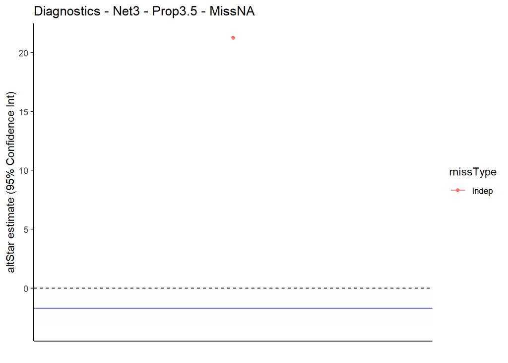

```r
# and see if the plot here matches the one above
missCaterpillarPlot(plotData = testPlotData,
                    truePara = tempTruePara,
                    trueSe = tempTrueSe,
                    chosenPara = "altStar",
                    chosenNetInd = chosenNetInd,
                    chosenProp = chunkMissPropFloat,
                    chosenMiss = chosenMissValue) %>%
  print()
```

```r
# still need to take out true parameter values
chosenPara = 3

tempTruePara = trueCoefList[[chosenNetInd]][chosenPara]
tempTrueSe = trueSeList[[chosenNetInd]][chosenPara]


# test run of the plot function
testPlotData = prepMissPlot(modelResList = modelResList,
                            modelSeList = modelSeList,
                            missModelList = missModelList,
                            propMissList = propMissList,
                            chosenProp = chunkMissProp,
                            chosenPara = "gwesp")

head(testPlotData)
```

```
##   parameter SE missModel
## 1  2.785266 NA     Indep
```

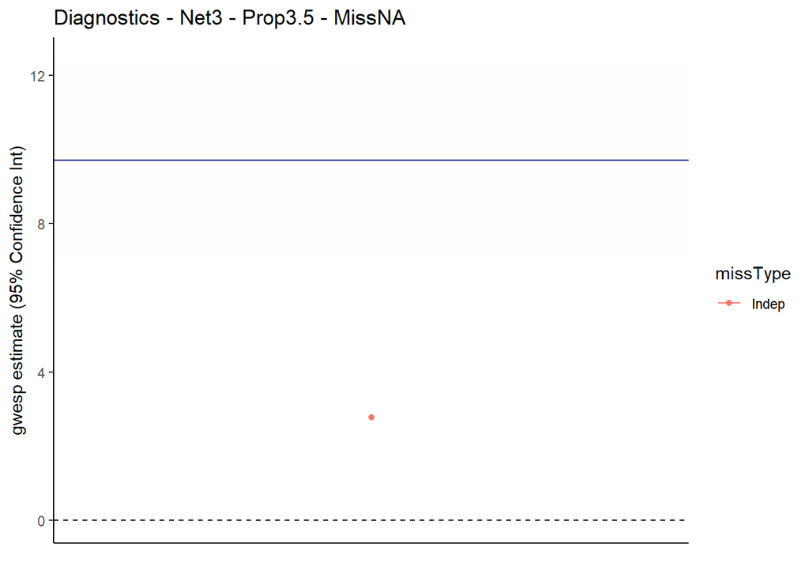

```r
# and see if the plot here matches the one above
missCaterpillarPlot(plotData = testPlotData,
                    truePara = tempTruePara,
                    trueSe = tempTrueSe,
                    chosenPara = "gwesp",
                    chosenNetInd = chosenNetInd,
                    chosenProp = chunkMissPropFloat,
                    chosenMiss = chosenMissValue) %>%
  print()
```

```r
# a temporary data frame from the output to be binded to the big data frame
tempFailData = prepFailPlot(propMissList = propMissList,
                            missModelList = missModelList,
                            chosenNetInd = chosenNetInd,
                            chosenProp = chunkMissProp,
                            chosenMiss = chosenMissValue)

# and bind it
failRateData = rbind(failRateData, tempFailData)
```

### 35% Peter

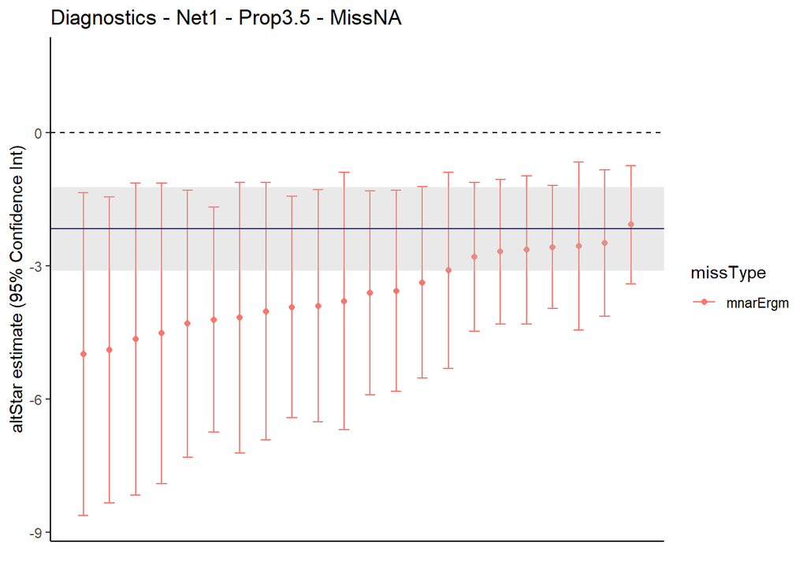

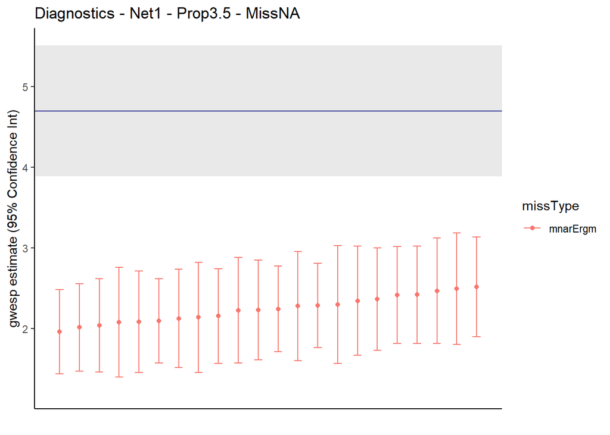

```r
# 35% missingness
# loading in the output results
outputList = list.files(here("Output", "20230825_simMissReest", "Peter"))

# applying the code above to different reestimations
# TODO: specify the missingness saved for current chunk, 1 = "NA"/peter, 2 = "0"/Todd
chunkMissSave = 1

# TODO: specify the chosen missingness proportion for each chunk (1/3 or 3.5/6)
chunkMissProp = 3
chunkMissPropFloat = 3.5 # specifically for 35% missingness because I regex by taking the first number next to 'prop'.

# take out the index for the chosen missingness saved value
chosenMissLabel = missSaveLabel[chunkMissSave]
chosenMissValue = missSaveValue[chunkMissSave]


# now looping with a specific vector of applicable networks
# TODO: specify the UCINet networks for the chunk, these are networks with enough re-estimations
chunkNetworks = c(1)

# note:
# net 3 is still so messed up it has three converged estimation for this set (out of 200)
# 20231010_missNetReest_net3_missModel2_prop3.5_trial11.RData
# 20231010_missNetReest_net3_missModel3_prop3.5_trial12.RData
# 20231010_missNetReest_net3_missModel3_prop3.5_trial19.RData

# no mnars, so the loop won't work.

# handle fail rates separately. these data structures are very unstandardised.

# TODO: vector of file names for regex
chunkRdataNames = c("20231005_missNetReest_net")

chunkMnarNames = c("20231011_missErgmNetReest_Miss")

# loop for all specified networks
for(chunkInd in 1:length(chunkNetworks)){

  # make sure the re-estimation lists are empty in the beginning
  modelResList = list()
  modelSeList = list()
  missModelList = list()
  propMissList = list()

  # set a specific index for the network
  chosenNetInd = chunkNetworks[chunkInd]

  # file list for the chosen network index
  chosenNetOutFiles = grep(paste(chunkRdataNames[chunkInd], chosenNetInd, sep =""), outputList)

  ## regex the MNAR files
  chosenMnarOutFiles = grep(paste(chunkMnarNames[chunkInd], chosenMissLabel, "_net", chosenNetInd, sep = ""), outputList)

  # combine the two indices
  combinedNetOutList = c(chosenNetOutFiles, chosenMnarOutFiles)

  # check to make sure there aren't any duplicates
  if( length(unique(combinedNetOutList)) != length(combinedNetOutList)){
    stop("Duplicate re-estimation datafiles! BAD.")
  }

  # loop to load
  chosenNetOutList = outputList[combinedNetOutList]

  for(fileInd in 1:length(chosenNetOutList)){
    # load all files
    load(here("Output", "20230825_simMissReest", chosenMissLabel, chosenNetOutList[fileInd]))

    # suppress these version difference warnings.
    suppressWarnings({
    modelResList[[fileInd]] = modelres$coefficients
    modelSeList[[fileInd]] = summary(modelres)$coefficients[,2]

    })

    # slight difference for the chosenMnarOutFiles because missModelList[[fileInd]] = always 4 (let 2 be mar ergm, 4 be mnar ergm)

    # this branch *should* be setting the miss model to 4 if they were regexed to be a part of the mnar list.
    if(combinedNetOutList[fileInd] %in% chosenMnarOutFiles){
     missModelList[[fileInd]] = 4
    } else {
     missModelList[[fileInd]] = as.integer(sub(".*?_missModel.*?(\\d+).*", "\\1", chosenNetOutList[[fileInd]]))
    }

    # propmiss should be the same
    propMissList[[fileInd]] = as.integer(sub(".*?_prop.*?(\\d+).*", "\\1", chosenNetOutList[[fileInd]]))
  }

  # first try with alt star
  chosenPara = 2

  tempTruePara = trueCoefList[[chosenNetInd]][chosenPara]
  tempTrueSe = trueSeList[[chosenNetInd]][chosenPara]


  # test run of the plot function
  testPlotData = prepMissPlot(modelResList = modelResList,
                              modelSeList = modelSeList,
                              missModelList = missModelList,
                              propMissList = propMissList,
                              chosenProp = chunkMissProp,
                              chosenPara = "altStar")

  head(testPlotData)


  # and see if the plot here matches the one above
  missCaterpillarPlot(plotData = testPlotData,
                      truePara = tempTruePara,
                      trueSe = tempTrueSe,
                      chosenPara = "altStar",
                      chosenNetInd = chosenNetInd,
                      chosenProp = chunkMissPropFloat,
                      chosenMiss = chosenMissValue) %>%
    print()




  # still need to take out true parameter values
  chosenPara = 3

  tempTruePara = trueCoefList[[chosenNetInd]][chosenPara]
  tempTrueSe = trueSeList[[chosenNetInd]][chosenPara]


  # test run of the plot function
  testPlotData = prepMissPlot(modelResList = modelResList,
                              modelSeList = modelSeList,
                              missModelList = missModelList,
                              propMissList = propMissList,
                              chosenProp = chunkMissProp,
                              chosenPara = "gwesp")

  head(testPlotData)


  # and see if the plot here matches the one above
  missCaterpillarPlot(plotData = testPlotData,
                      truePara = tempTruePara,
                      trueSe = tempTrueSe,
                      chosenPara = "gwesp",
                      chosenNetInd = chosenNetInd,
                      chosenProp = chunkMissPropFloat,
                      chosenMiss = chosenMissValue) %>%
    print()

  # a temporary data frame from the output to be binded to the big data frame
  tempFailData = prepFailPlot(propMissList = propMissList,
                              missModelList = missModelList,
                              chosenNetInd = chosenNetInd,
                              chosenProp = chunkMissProp,
                              chosenMiss = chosenMissValue)

  # and bind it
  failRateData = rbind(failRateData, tempFailData)

}
```

```r
### A section specifically for the three re-estimations of net3 that made it
# no MNAR files, so removing them from the code below

# make sure the re-estimation lists are empty in the beginning
modelResList = list()
modelSeList = list()
missModelList = list()
propMissList = list()

# set a specific index for the network
chosenNetInd = 3

# file list for the chosen network index
chosenNetOutFiles = grep(paste("20231010_missNetReest_net", chosenNetInd, sep =""), outputList)


# loop to load
chosenNetOutList = outputList[chosenNetOutFiles]

for(fileInd in 1:length(chosenNetOutList)){
  # load all files
  load(here("Output", "20230825_simMissReest", chosenMissLabel, chosenNetOutList[fileInd]))

  # suppress these version difference warnings.
  suppressWarnings({
  modelResList[[fileInd]] = modelres$coefficients
  modelSeList[[fileInd]] = summary(modelres)$coefficients[,2]

  })

   missModelList[[fileInd]] = as.integer(sub(".*?_missModel.*?(\\d+).*", "\\1", chosenNetOutList[[fileInd]]))

  # propmiss should be the same
  propMissList[[fileInd]] = as.integer(sub(".*?_prop.*?(\\d+).*", "\\1", chosenNetOutList[[fileInd]]))
}

# first try with alt star
chosenPara = 2

tempTruePara = trueCoefList[[chosenNetInd]][chosenPara]
tempTrueSe = trueSeList[[chosenNetInd]][chosenPara]


# test run of the plot function
testPlotData = prepMissPlot(modelResList = modelResList,
                            modelSeList = modelSeList,
                            missModelList = missModelList,
                            propMissList = propMissList,
                            chosenProp = chunkMissProp,
                            chosenPara = "altStar")

head(testPlotData)
```

```
##   parameter SE missModel
## 1 15.661456 NA   marErgm
## 2  1.350935 NA    Latent
## 3  5.424564 NA    Latent
```

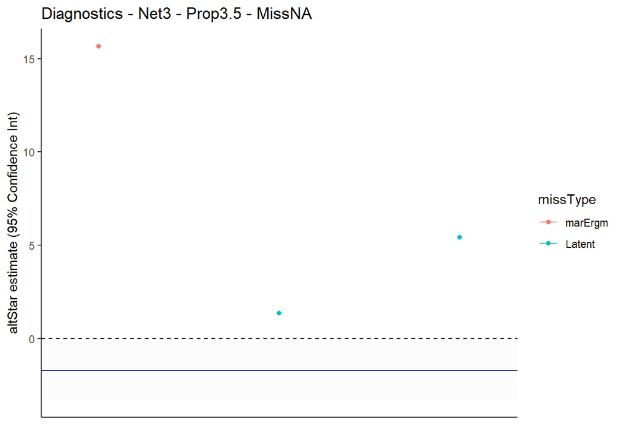

```r
# and see if the plot here matches the one above
missCaterpillarPlot(plotData = testPlotData,
                    truePara = tempTruePara,
                    trueSe = tempTrueSe,
                    chosenPara = "altStar",
                    chosenNetInd = chosenNetInd,
                    chosenProp = chunkMissPropFloat,
                    chosenMiss = chosenMissValue) %>%
  print()
```

```r
# still need to take out true parameter values
chosenPara = 3

tempTruePara = trueCoefList[[chosenNetInd]][chosenPara]
tempTrueSe = trueSeList[[chosenNetInd]][chosenPara]


# test run of the plot function
testPlotData = prepMissPlot(modelResList = modelResList,
                            modelSeList = modelSeList,
                            missModelList = missModelList,
                            propMissList = propMissList,
                            chosenProp = chunkMissProp,
                            chosenPara = "gwesp")

head(testPlotData)
```

```
##    parameter SE missModel
## 1 -0.2770482 NA   marErgm
## 3 -1.1609499 NA    Latent
## 2 12.4001035 NA    Latent
```

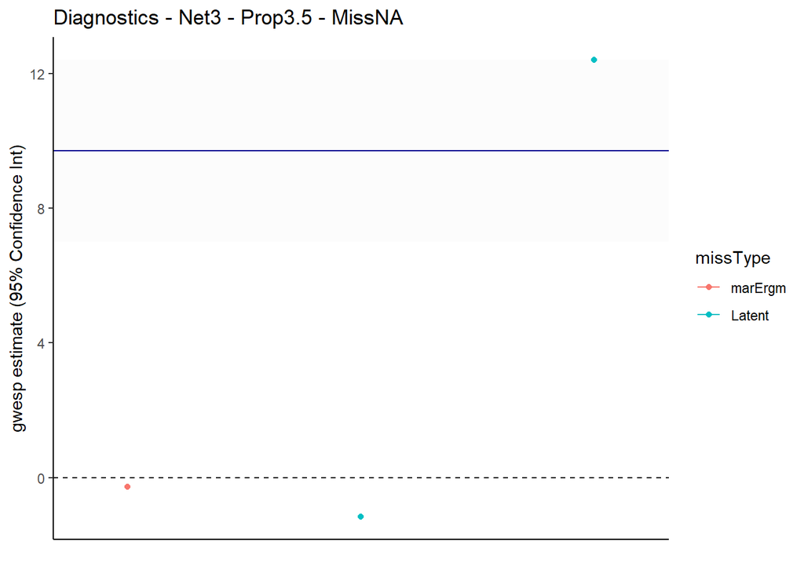

```r
# and see if the plot here matches the one above
missCaterpillarPlot(plotData = testPlotData,
                    truePara = tempTruePara,
                    trueSe = tempTrueSe,
                    chosenPara = "gwesp",
                    chosenNetInd = chosenNetInd,
                    chosenProp = chunkMissPropFloat,
                    chosenMiss = chosenMissValue) %>%
  print()
```

```r
# a temporary data frame from the output to be binded to the big data frame
tempFailData = prepFailPlot(propMissList = propMissList,
                            missModelList = missModelList,
                            chosenNetInd = chosenNetInd,
                            chosenProp = chunkMissProp,
                            chosenMiss = chosenMissValue)

# and bind it
failRateData = rbind(failRateData, tempFailData)
```

### 60% Peter

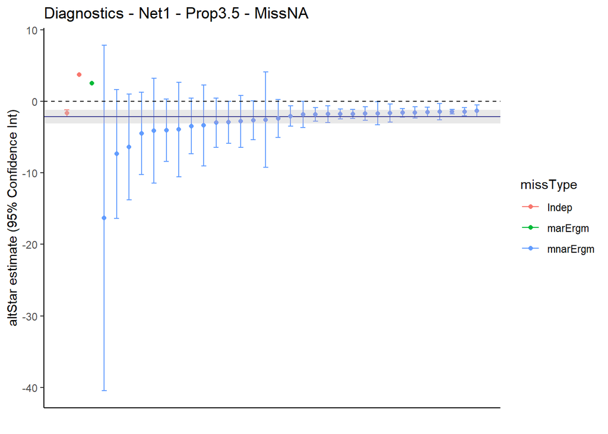

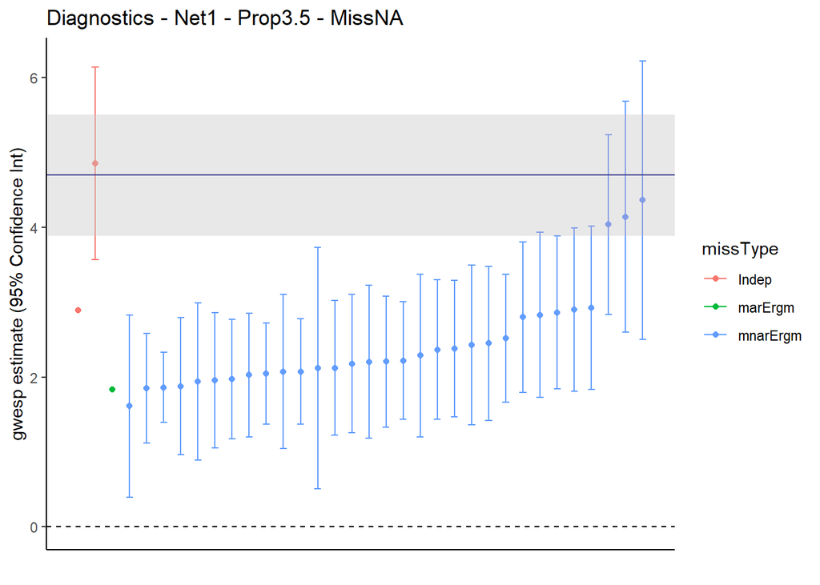

```r
# 60% Peter
# loading in the output results
outputList = list.files(here("Output", "20230825_simMissReest", "Peter"))

# applying the code above to different reestimations
# TODO: specify the missingness saved for current chunk, 1 = "NA"/peter, 2 = "0"/Todd
chunkMissSave = 1

# TODO: specify the chosen missingness proportion for each chunk (1/3 or 3.5/6)
chunkMissProp = 6

# take out the index for the chosen missingness saved value
chosenMissLabel = missSaveLabel[chunkMissSave]
chosenMissValue = missSaveValue[chunkMissSave]


# now looping with a specific vector of applicable networks
# TODO: specify the UCINet networks for the chunk, these are networks with enough re-estimations
chunkNetworks = c(1)

# note:
# net 3 is still so messed up it has two converged estimation for this set (out of 200)
# 20231011_missNetReest_net3_missModel2_prop6_trial40
# 20231011_missNetReest_net3_missModel3_prop6_trial46

# no mnars, so the loop won't work.

# handle fail rates separately. these data structures are very unstandardised.

# TODO: vector of file names for regex
chunkRdataNames = c("20231005_missNetReest_net")

chunkMnarNames = c("20231012_missErgmNetReest_Miss")

# loop for all specified networks
for(chunkInd in 1:length(chunkNetworks)){

  # make sure the re-estimation lists are empty in the beginning
  modelResList = list()
  modelSeList = list()
  missModelList = list()
  propMissList = list()

  # set a specific index for the network
  chosenNetInd = chunkNetworks[chunkInd]

  # file list for the chosen network index
  chosenNetOutFiles = grep(paste(chunkRdataNames[chunkInd], chosenNetInd, sep =""), outputList)

  ## regex the MNAR files
  chosenMnarOutFiles = grep(paste(chunkMnarNames[chunkInd], chosenMissLabel, "_net", chosenNetInd, sep = ""), outputList)

  # combine the two indices
  combinedNetOutList = c(chosenNetOutFiles, chosenMnarOutFiles)

  # check to make sure there aren't any duplicates
  if( length(unique(combinedNetOutList)) != length(combinedNetOutList)){
    stop("Duplicate re-estimation datafiles! BAD.")
  }

  # loop to load
  chosenNetOutList = outputList[combinedNetOutList]

  for(fileInd in 1:length(chosenNetOutList)){
    # load all files
    load(here("Output", "20230825_simMissReest", chosenMissLabel, chosenNetOutList[fileInd]))

    # suppress these version difference warnings.
    suppressWarnings({
    modelResList[[fileInd]] = modelres$coefficients
    modelSeList[[fileInd]] = summary(modelres)$coefficients[,2]

    })

    # slight difference for the chosenMnarOutFiles because missModelList[[fileInd]] = always 4 (let 2 be mar ergm, 4 be mnar ergm)

    # this branch *should* be setting the miss model to 4 if they were regexed to be a part of the mnar list.
    if(combinedNetOutList[fileInd] %in% chosenMnarOutFiles){
     missModelList[[fileInd]] = 4
    } else {
     missModelList[[fileInd]] = as.integer(sub(".*?_missModel.*?(\\d+).*", "\\1", chosenNetOutList[[fileInd]]))
    }

    # propmiss should be the same
    propMissList[[fileInd]] = as.integer(sub(".*?_prop.*?(\\d+).*", "\\1", chosenNetOutList[[fileInd]]))
  }

  # first try with alt star
  chosenPara = 2

  tempTruePara = trueCoefList[[chosenNetInd]][chosenPara]
  tempTrueSe = trueSeList[[chosenNetInd]][chosenPara]


  # test run of the plot function
  testPlotData = prepMissPlot(modelResList = modelResList,
                              modelSeList = modelSeList,
                              missModelList = missModelList,
                              propMissList = propMissList,
                              chosenProp = chunkMissProp,
                              chosenPara = "altStar")

  head(testPlotData)


  # and see if the plot here matches the one above
  missCaterpillarPlot(plotData = testPlotData,
                      truePara = tempTruePara,
                      trueSe = tempTrueSe,
                      chosenPara = "altStar",
                      chosenNetInd = chosenNetInd,
                      chosenProp = chunkMissPropFloat,
                      chosenMiss = chosenMissValue) %>%
    print()




  # still need to take out true parameter values
  chosenPara = 3

  tempTruePara = trueCoefList[[chosenNetInd]][chosenPara]
  tempTrueSe = trueSeList[[chosenNetInd]][chosenPara]


  # test run of the plot function
  testPlotData = prepMissPlot(modelResList = modelResList,
                              modelSeList = modelSeList,
                              missModelList = missModelList,
                              propMissList = propMissList,
                              chosenProp = chunkMissProp,
                              chosenPara = "gwesp")

  head(testPlotData)


  # and see if the plot here matches the one above
  missCaterpillarPlot(plotData = testPlotData,
                      truePara = tempTruePara,
                      trueSe = tempTrueSe,
                      chosenPara = "gwesp",
                      chosenNetInd = chosenNetInd,
                      chosenProp = chunkMissPropFloat,
                      chosenMiss = chosenMissValue) %>%
    print()

  # a temporary data frame from the output to be binded to the big data frame
  tempFailData = prepFailPlot(propMissList = propMissList,
                              missModelList = missModelList,
                              chosenNetInd = chosenNetInd,
                              chosenProp = chunkMissProp,
                              chosenMiss = chosenMissValue)

  # and bind it
  failRateData = rbind(failRateData, tempFailData)

}
```

```r
### A section specifically for the three re-estimations of net3 that made it
# no MNAR files, so removing them from the code below

# make sure the re-estimation lists are empty in the beginning
modelResList = list()
modelSeList = list()
missModelList = list()
propMissList = list()

# set a specific index for the network
chosenNetInd = 3

# file list for the chosen network index
chosenNetOutFiles = grep(paste("20231011_missNetReest_net", chosenNetInd, sep =""), outputList)


# loop to load
chosenNetOutList = outputList[chosenNetOutFiles]

for(fileInd in 1:length(chosenNetOutList)){
  # load all files
  load(here("Output", "20230825_simMissReest", chosenMissLabel, chosenNetOutList[fileInd]))

  # suppress these version difference warnings.
  suppressWarnings({
  modelResList[[fileInd]] = modelres$coefficients
  modelSeList[[fileInd]] = summary(modelres)$coefficients[,2]

  })

   missModelList[[fileInd]] = as.integer(sub(".*?_missModel.*?(\\d+).*", "\\1", chosenNetOutList[[fileInd]]))

  # propmiss should be the same
  propMissList[[fileInd]] = as.integer(sub(".*?_prop.*?(\\d+).*", "\\1", chosenNetOutList[[fileInd]]))
}

# first try with alt star
chosenPara = 2

tempTruePara = trueCoefList[[chosenNetInd]][chosenPara]
tempTrueSe = trueSeList[[chosenNetInd]][chosenPara]


# test run of the plot function
testPlotData = prepMissPlot(modelResList = modelResList,
                            modelSeList = modelSeList,
                            missModelList = missModelList,
                            propMissList = propMissList,
                            chosenProp = chunkMissProp,
                            chosenPara = "altStar")

head(testPlotData)
```

```
##   parameter SE missModel
## 1  2.548622 NA   marErgm
## 2 17.492617 NA    Latent
```

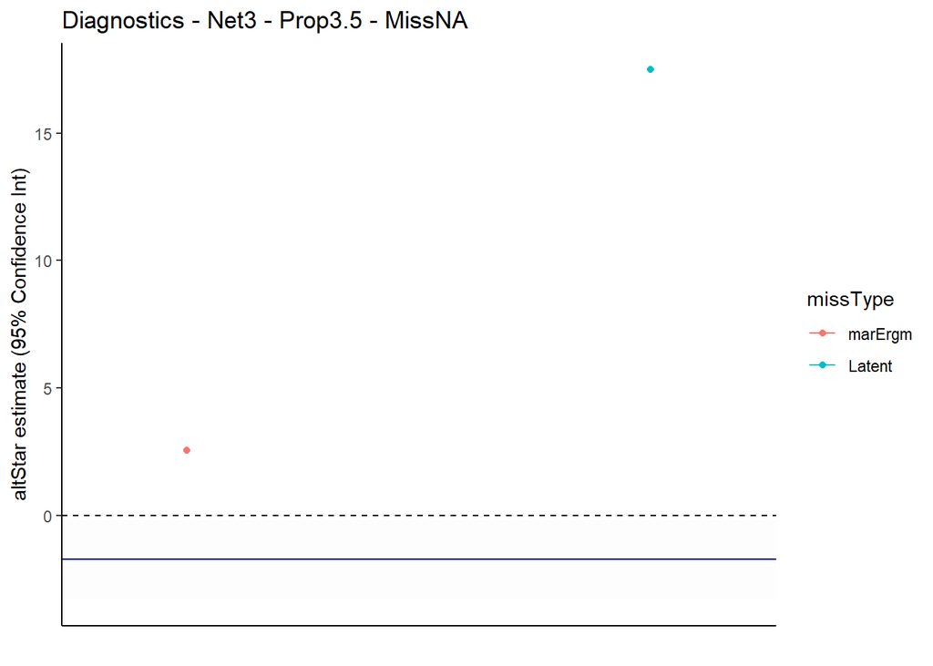

```r
# and see if the plot here matches the one above
missCaterpillarPlot(plotData = testPlotData,
                    truePara = tempTruePara,
                    trueSe = tempTrueSe,
                    chosenPara = "altStar",
                    chosenNetInd = chosenNetInd,
                    chosenProp = chunkMissPropFloat,
                    chosenMiss = chosenMissValue) %>%
  print()
```

```r
# still need to take out true parameter values
chosenPara = 3

tempTruePara = trueCoefList[[chosenNetInd]][chosenPara]
tempTrueSe = trueSeList[[chosenNetInd]][chosenPara]


# test run of the plot function
testPlotData = prepMissPlot(modelResList = modelResList,
                            modelSeList = modelSeList,
                            missModelList = missModelList,
                            propMissList = propMissList,
                            chosenProp = chunkMissProp,
                            chosenPara = "gwesp")

head(testPlotData)
```

```
##   parameter SE missModel
## 1 -1.027786 NA   marErgm
## 2 -2.287233 NA    Latent
```

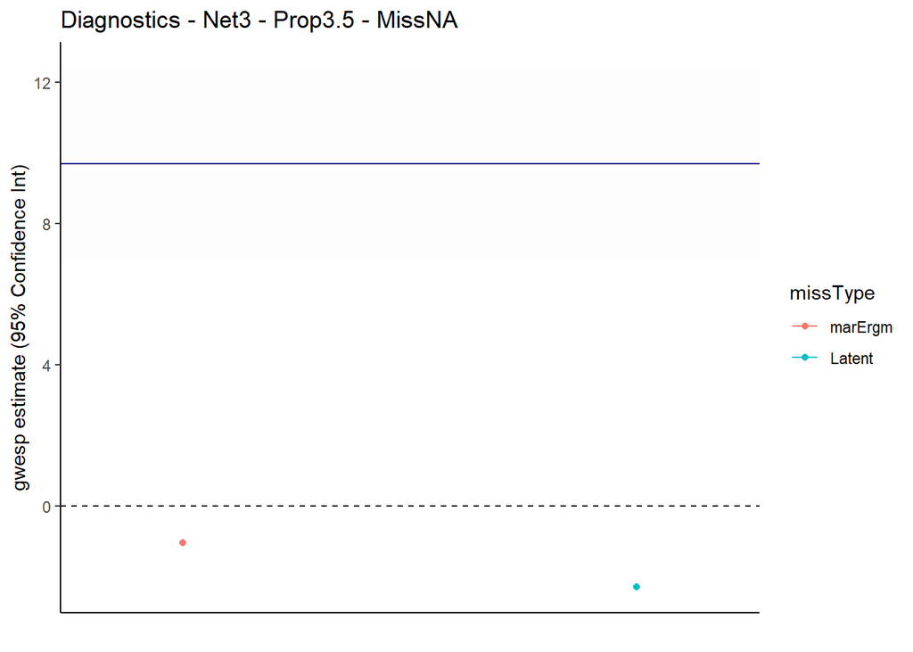

```r
# and see if the plot here matches the one above
missCaterpillarPlot(plotData = testPlotData,
                    truePara = tempTruePara,
                    trueSe = tempTrueSe,
                    chosenPara = "gwesp",
                    chosenNetInd = chosenNetInd,
                    chosenProp = chunkMissPropFloat,
                    chosenMiss = chosenMissValue) %>%
  print()
```

```r
# a temporary data frame from the output to be binded to the big data frame
tempFailData = prepFailPlot(propMissList = propMissList,
                            missModelList = missModelList,
                            chosenNetInd = chosenNetInd,
                            chosenProp = chunkMissProp,
                            chosenMiss = chosenMissValue)

# and bind it
failRateData = rbind(failRateData, tempFailData)
```

### 10% Todd

Literally nothing. No successful re-estimations for any missingness model for net 3.

### 35% Todd

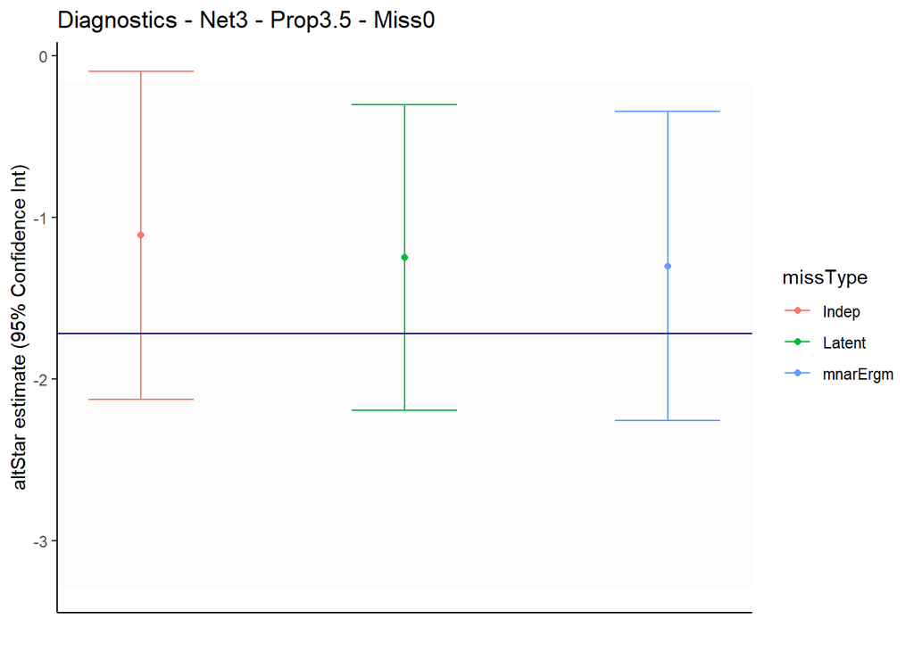

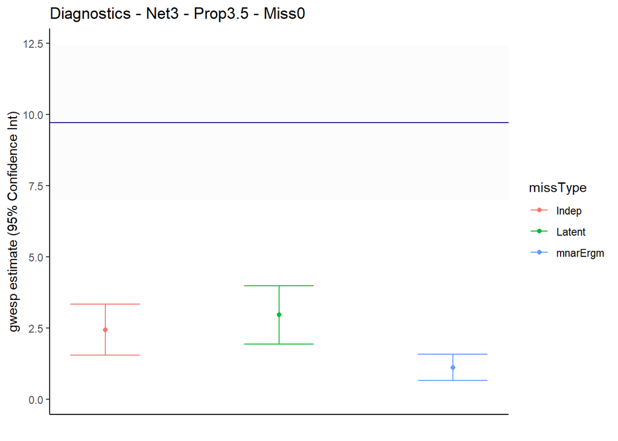

```r
# 35% missingness - Todd
# loading in the output results
outputList = list.files(here("Output", "20230825_simMissReest", "TOdd"))

# applying the code above to different reestimations
# TODO: specify the missingness saved for current chunk, 1 = "NA"/peter, 2 = "0"/Todd
chunkMissSave = 2

# TODO: specify the chosen missingness proportion for each chunk (1/3 or 3.5/6)
chunkMissProp = 3
chunkMissPropFloat = 3.5


# take out the index for the chosen missingness saved value
chosenMissLabel = missSaveLabel[chunkMissSave]
chosenMissValue = missSaveValue[chunkMissSave]


# now looping with a specific vector of applicable networks
# TODO: specify the UCINet networks for the chunk, these are networks with enough re-estimations
chunkNetworks = 3

# handle fail rates separately. these data structures are very unstandardised.

# TODO: vector of file names for regex
chunkRdataNames = c("20231005_missNetReest_net")

chunkMnarNames = c("20231012_missErgmNetReest_Miss")

# loop for all specified networks
for(chunkInd in 1:length(chunkNetworks)){

  # make sure the re-estimation lists are empty in the beginning
  modelResList = list()
  modelSeList = list()
  missModelList = list()
  propMissList = list()

  # set a specific index for the network
  chosenNetInd = chunkNetworks[chunkInd]

  # file list for the chosen network index
  chosenNetOutFiles = grep(paste(chunkRdataNames[chunkInd], chosenNetInd, sep =""), outputList)

  ## regex the MNAR files
  chosenMnarOutFiles = grep(paste(chunkMnarNames[chunkInd], chosenMissLabel, "_net", chosenNetInd, sep = ""), outputList)

  # combine the two indices
  combinedNetOutList = c(chosenNetOutFiles, chosenMnarOutFiles)

  # check to make sure there aren't any duplicates
  if( length(unique(combinedNetOutList)) != length(combinedNetOutList)){
    stop("Duplicate re-estimation datafiles! BAD.")
  }

  # loop to load
  chosenNetOutList = outputList[combinedNetOutList]

  for(fileInd in 1:length(chosenNetOutList)){
    # load all files
    load(here("Output", "20230825_simMissReest", chosenMissLabel, chosenNetOutList[fileInd]))

    # suppress these version difference warnings.
    suppressWarnings({
    modelResList[[fileInd]] = modelres$coefficients
    modelSeList[[fileInd]] = summary(modelres)$coefficients[,2]

    })

    # slight difference for the chosenMnarOutFiles because missModelList[[fileInd]] = always 4 (let 2 be mar ergm, 4 be mnar ergm)

    # this branch *should* be setting the miss model to 4 if they were regexed to be a part of the mnar list.
    if(combinedNetOutList[fileInd] %in% chosenMnarOutFiles){
     missModelList[[fileInd]] = 4
    } else {
     missModelList[[fileInd]] = as.integer(sub(".*?_missModel.*?(\\d+).*", "\\1", chosenNetOutList[[fileInd]]))
    }

    # propmiss should be the same
    propMissList[[fileInd]] = as.integer(sub(".*?_prop.*?(\\d+).*", "\\1", chosenNetOutList[[fileInd]]))
  }

  # first try with alt star
  chosenPara = 2

  tempTruePara = trueCoefList[[chosenNetInd]][chosenPara]
  tempTrueSe = trueSeList[[chosenNetInd]][chosenPara]


  # test run of the plot function
  testPlotData = prepMissPlot(modelResList = modelResList,
                              modelSeList = modelSeList,
                              missModelList = missModelList,
                              propMissList = propMissList,
                              chosenProp = chunkMissProp,
                              chosenPara = "altStar")

  head(testPlotData)


  # and see if the plot here matches the one above
  missCaterpillarPlot(plotData = testPlotData,
                      truePara = tempTruePara,
                      trueSe = tempTrueSe,
                      chosenPara = "altStar",
                      chosenNetInd = chosenNetInd,
                      chosenProp = chunkMissPropFloat,
                      chosenMiss = chosenMissValue) %>%
    print()




  # still need to take out true parameter values
  chosenPara = 3

  tempTruePara = trueCoefList[[chosenNetInd]][chosenPara]
  tempTrueSe = trueSeList[[chosenNetInd]][chosenPara]


  # test run of the plot function
  testPlotData = prepMissPlot(modelResList = modelResList,
                              modelSeList = modelSeList,
                              missModelList = missModelList,
                              propMissList = propMissList,
                              chosenProp = chunkMissProp,
                              chosenPara = "gwesp")

  head(testPlotData)


  # and see if the plot here matches the one above
  missCaterpillarPlot(plotData = testPlotData,
                      truePara = tempTruePara,
                      trueSe = tempTrueSe,
                      chosenPara = "gwesp",
                      chosenNetInd = chosenNetInd,
                      chosenProp = chunkMissPropFloat,
                      chosenMiss = chosenMissValue) %>%
    print()

  # a temporary data frame from the output to be binded to the big data frame
  tempFailData = prepFailPlot(propMissList = propMissList,
                              missModelList = missModelList,
                              chosenNetInd = chosenNetInd,
                              chosenProp = chunkMissProp,
                              chosenMiss = chosenMissValue)

  # and bind it
  failRateData = rbind(failRateData, tempFailData)

}
```

### 60% Todd

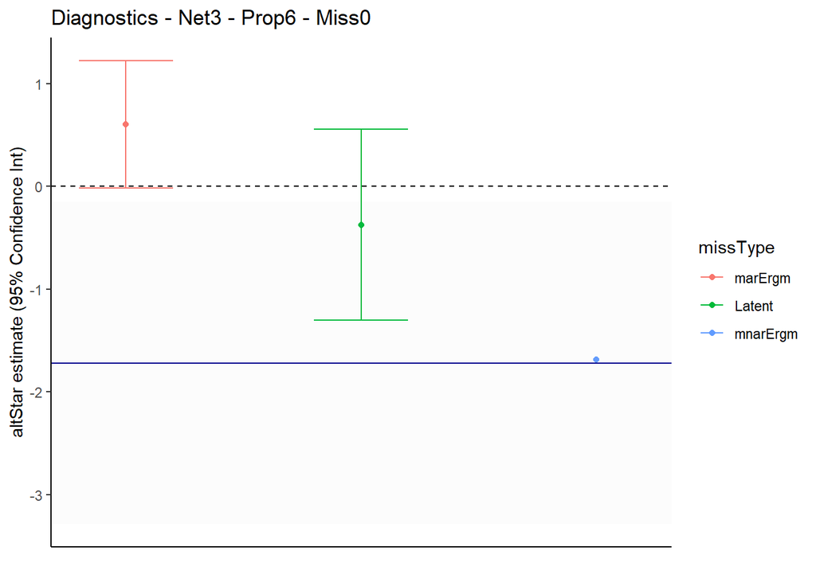

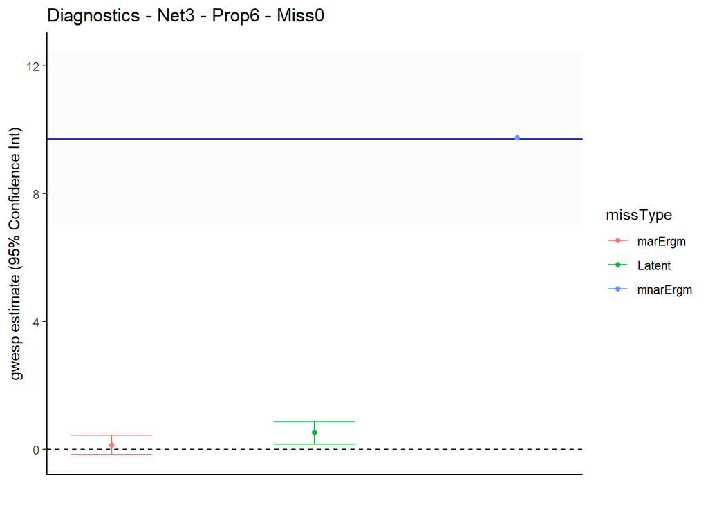

```r
# 35% missingness - Todd
# loading in the output results
outputList = list.files(here("Output", "20230825_simMissReest", "TOdd"))

# applying the code above to different reestimations
# TODO: specify the missingness saved for current chunk, 1 = "NA"/peter, 2 = "0"/Todd
chunkMissSave = 2

# TODO: specify the chosen missingness proportion for each chunk (1/3 or 3.5/6)
chunkMissProp = 6


# take out the index for the chosen missingness saved value
chosenMissLabel = missSaveLabel[chunkMissSave]
chosenMissValue = missSaveValue[chunkMissSave]


# now looping with a specific vector of applicable networks
# TODO: specify the UCINet networks for the chunk, these are networks with enough re-estimations
chunkNetworks = 3

# note:
# net 3 is so messed up it has ONE converged estimation for this set
# 20231010_missNetReest_net3_missModel1_prop1_trial9.RData

# handle fail rates separately. these data structures are very unstandardised.

# TODO: vector of file names for regex
chunkRdataNames = c("20231006_missNetReest_net")

chunkMnarNames = c("20231012_missErgmNetReest_Miss")

# loop for all specified networks
for(chunkInd in 1:length(chunkNetworks)){

  # make sure the re-estimation lists are empty in the beginning
  modelResList = list()
  modelSeList = list()
  missModelList = list()
  propMissList = list()

  # set a specific index for the network
  chosenNetInd = chunkNetworks[chunkInd]

  # file list for the chosen network index
  chosenNetOutFiles = grep(paste(chunkRdataNames[chunkInd], chosenNetInd, sep =""), outputList)

  ## regex the MNAR files
  chosenMnarOutFiles = grep(paste(chunkMnarNames[chunkInd], chosenMissLabel, "_net", chosenNetInd, sep = ""), outputList)

  # combine the two indices
  combinedNetOutList = c(chosenNetOutFiles, chosenMnarOutFiles)

  # check to make sure there aren't any duplicates
  if( length(unique(combinedNetOutList)) != length(combinedNetOutList)){
    stop("Duplicate re-estimation datafiles! BAD.")
  }

  # loop to load
  chosenNetOutList = outputList[combinedNetOutList]

  for(fileInd in 1:length(chosenNetOutList)){
    # load all files
    load(here("Output", "20230825_simMissReest", chosenMissLabel, chosenNetOutList[fileInd]))

    # suppress these version difference warnings.
    suppressWarnings({
    modelResList[[fileInd]] = modelres$coefficients
    modelSeList[[fileInd]] = summary(modelres)$coefficients[,2]

    })

    # slight difference for the chosenMnarOutFiles because missModelList[[fileInd]] = always 4 (let 2 be mar ergm, 4 be mnar ergm)

    # this branch *should* be setting the miss model to 4 if they were regexed to be a part of the mnar list.
    if(combinedNetOutList[fileInd] %in% chosenMnarOutFiles){
     missModelList[[fileInd]] = 4
    } else {
     missModelList[[fileInd]] = as.integer(sub(".*?_missModel.*?(\\d+).*", "\\1", chosenNetOutList[[fileInd]]))
    }

    # propmiss should be the same
    propMissList[[fileInd]] = as.integer(sub(".*?_prop.*?(\\d+).*", "\\1", chosenNetOutList[[fileInd]]))
  }

  # first try with alt star
  chosenPara = 2

  tempTruePara = trueCoefList[[chosenNetInd]][chosenPara]
  tempTrueSe = trueSeList[[chosenNetInd]][chosenPara]


  # test run of the plot function
  testPlotData = prepMissPlot(modelResList = modelResList,
                              modelSeList = modelSeList,
                              missModelList = missModelList,
                              propMissList = propMissList,
                              chosenProp = chunkMissProp,
                              chosenPara = "altStar")

  head(testPlotData)


  # and see if the plot here matches the one above
  missCaterpillarPlot(plotData = testPlotData,
                      truePara = tempTruePara,
                      trueSe = tempTrueSe,
                      chosenPara = "altStar",
                      chosenNetInd = chosenNetInd,
                      chosenProp = chunkMissProp,
                      chosenMiss = chosenMissValue) %>%
    print()




  # still need to take out true parameter values
  chosenPara = 3

  tempTruePara = trueCoefList[[chosenNetInd]][chosenPara]
  tempTrueSe = trueSeList[[chosenNetInd]][chosenPara]


  # test run of the plot function
  testPlotData = prepMissPlot(modelResList = modelResList,
                              modelSeList = modelSeList,
                              missModelList = missModelList,
                              propMissList = propMissList,
                              chosenProp = chunkMissProp,
                              chosenPara = "gwesp")

  head(testPlotData)


  # and see if the plot here matches the one above
  missCaterpillarPlot(plotData = testPlotData,
                      truePara = tempTruePara,
                      trueSe = tempTrueSe,
                      chosenPara = "gwesp",
                      chosenNetInd = chosenNetInd,
                      chosenProp = chunkMissProp,
                      chosenMiss = chosenMissValue) %>%
    print()

  # a temporary data frame from the output to be binded to the big data frame
  tempFailData = prepFailPlot(propMissList = propMissList,
                              missModelList = missModelList,
                              chosenNetInd = chosenNetInd,
                              chosenProp = chunkMissProp,
                              chosenMiss = chosenMissValue)

  # and bind it
  failRateData = rbind(failRateData, tempFailData)

}
```

## Failure rate plot

### Wrangling

```r
# plotting the failure rate
# data frame for the completely failed missingness combinations
# just for the formatting
tempFailData = failRateData[1,]

# todd 10s
tempFailData[1, ] = c(1, 3, 1, 1, "0")
tempFailData[2, ] = c(1, 3, 2, 1, "0")
tempFailData[3, ] = c(1, 3, 3, 1, "0")
tempFailData[4, ] = c(1, 3, 4, 1, "0")

# peter 10s
tempFailData[5, ] = c(1, 1, 1, 1, "NA")
tempFailData[6, ] = c(1, 1, 2, 1, "NA")
tempFailData[7, ] = c(1, 1, 3, 1, "NA")
tempFailData[8, ] = c(1, 3, 2, 1, "NA")
tempFailData[9, ] = c(1, 3, 3, 1, "NA")
tempFailData[10, ] = c(1, 3, 4, 1, "NA")

# todd 35s
tempFailData[11, ] = c(1, 3, 2, 3, "0")

# peter 35s
tempFailData[12, ] = c(1, 1, 1, 3, "NA")
tempFailData[13, ] = c(1, 1, 2, 3, "NA")
tempFailData[14, ] = c(1, 1, 3, 3, "NA")
tempFailData[15, ] = c(1, 3, 1, 3, "NA")
tempFailData[16, ] = c(1, 3, 4, 3, "NA")

# todd 60
tempFailData[17, ] = c(1, 3, 1, 6, "0")

# peter 60
tempFailData[18, ] = c(1, 1, 3, 6, "NA")
tempFailData[19, ] = c(1, 3, 1, 6, "NA")
tempFailData[20, ] = c(1, 3, 4, 6, "NA")

# object type stuff
tempFailData$failRate = as.numeric(tempFailData$failRate)
tempFailData$netInd = as.numeric(tempFailData$netInd)
tempFailData$missModel = as.numeric(tempFailData$missModel)
tempFailData$missProp = as.numeric(tempFailData$missProp)

# and bind
failRateData = rbind(failRateData, tempFailData)

# check for duplicates
if(any(duplicated(failRateData))){

  # take only distinct elements
  failRateData = distinct(failRateData)
}



# give the fail rate data (keep it untouched) a unique variable for the combination of missingness
failRatePlotData = failRateData %>%
  group_by(missProp, missSave) %>%
  mutate(missCondition = cur_group_id()) %>%
  ungroup()


# turn variables into factors for plotting
failRatePlotData$missModel = factor(failRatePlotData$missModel, levels = c(1,2,3,4), labels = c("Indep", "marErgm", "Latent", "mnarErgm"))
failRatePlotData$missCondition =  factor(failRatePlotData$missCondition, levels = c(1,2,3,4,5,6), labels = c("Todd10", "Peter10", "Todd35", "Peter35", "Todd60", "Peter60"))
```

### Plotting

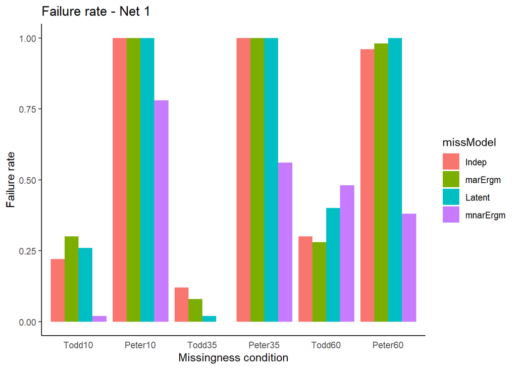

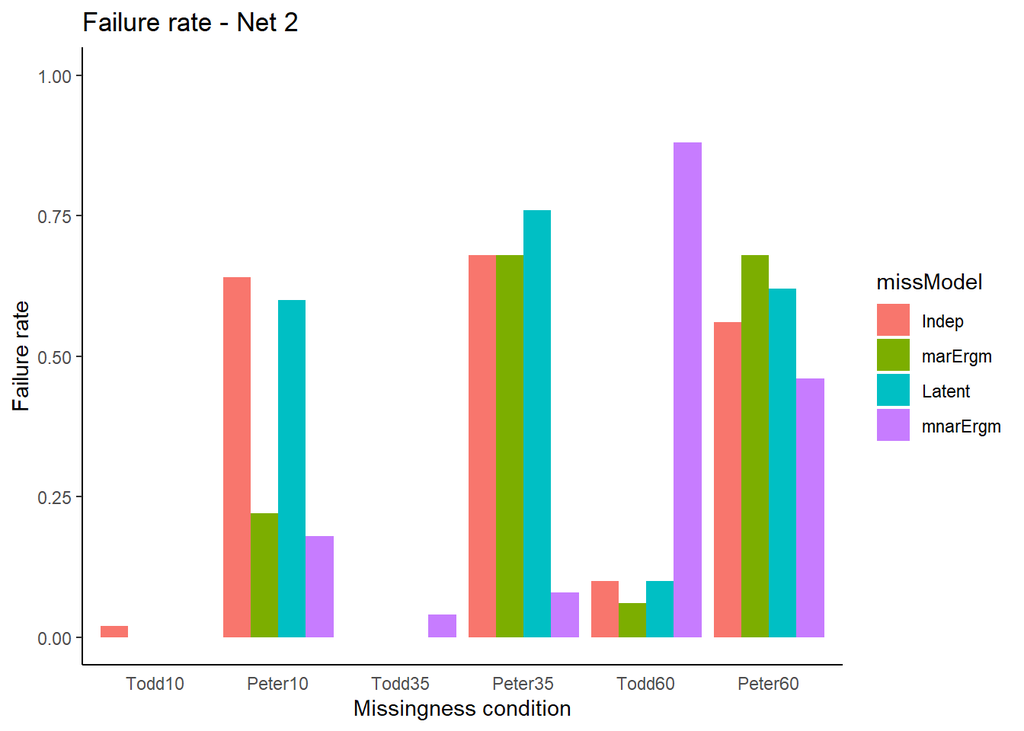

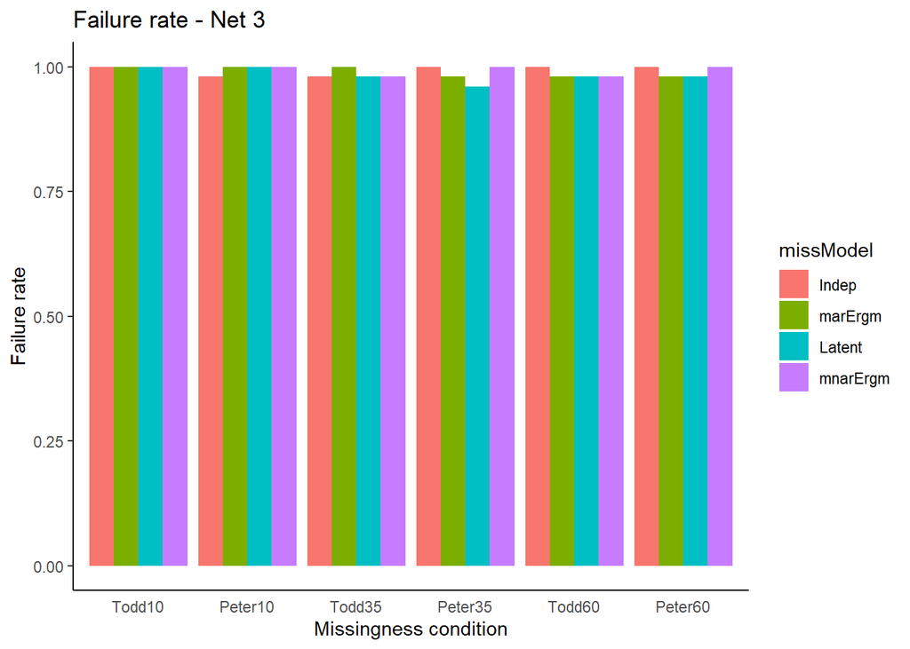

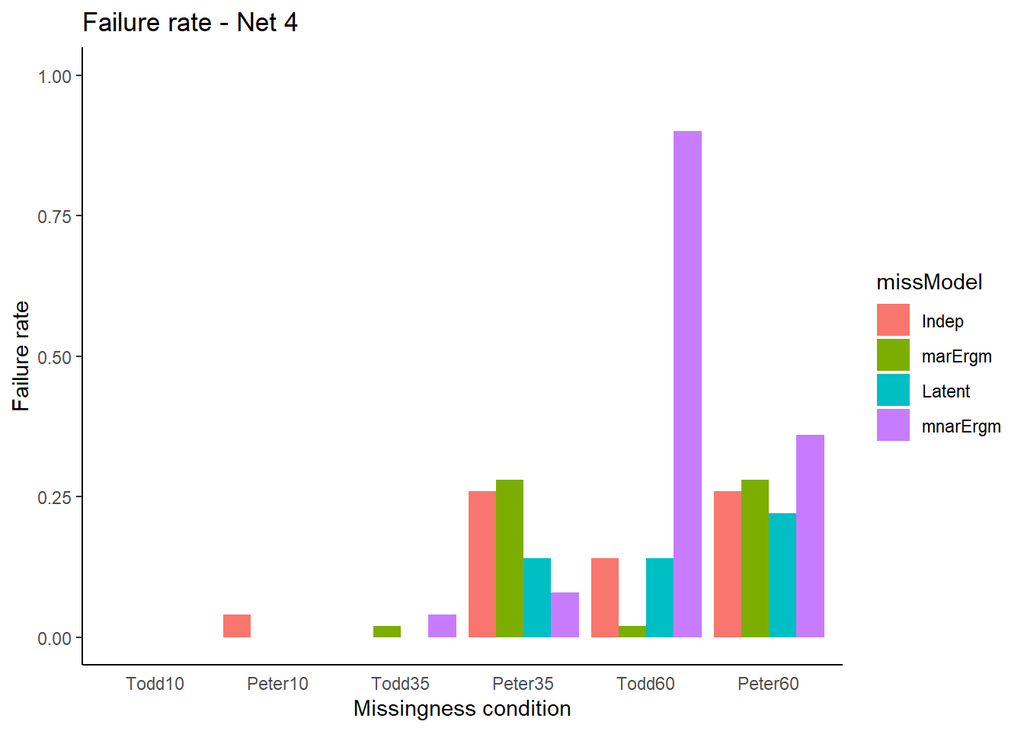

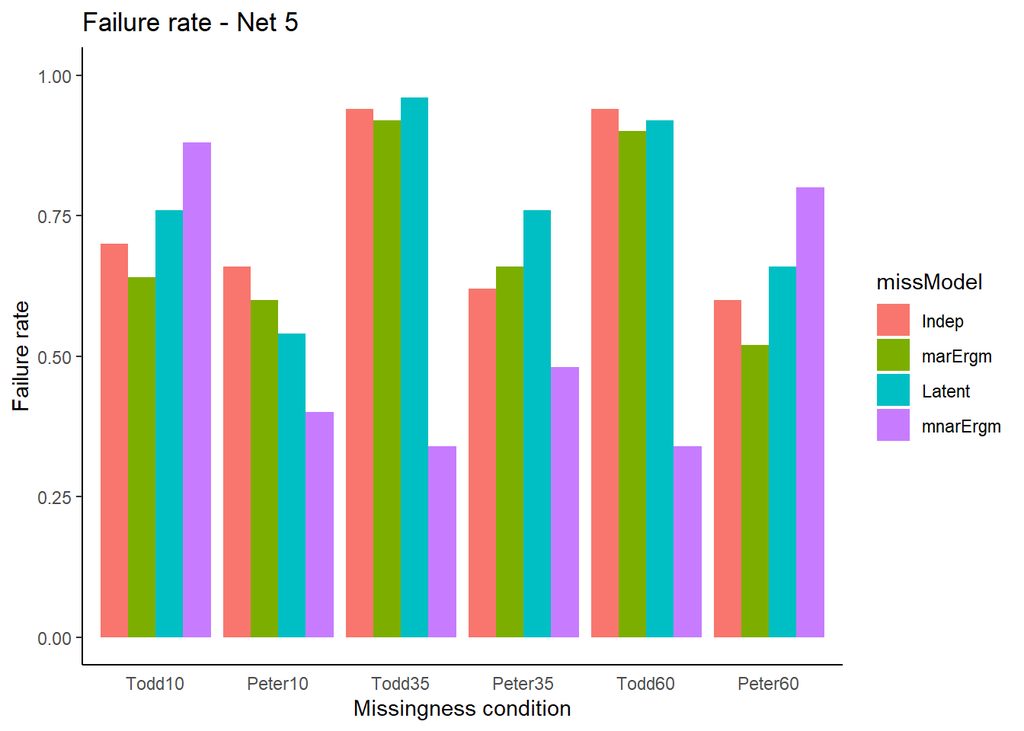

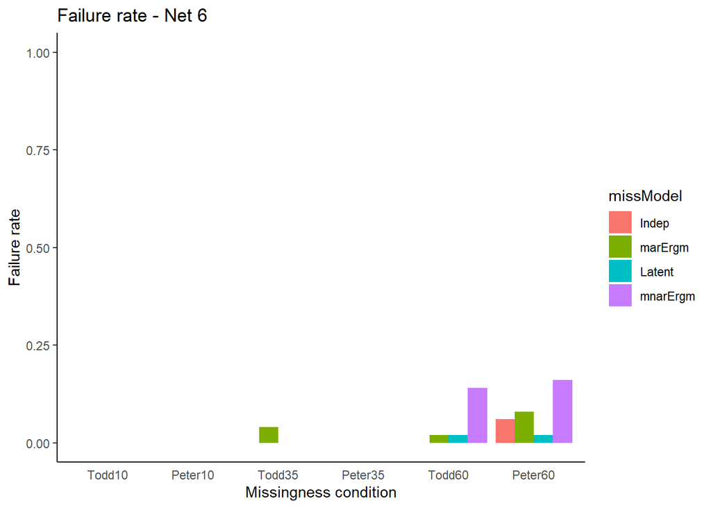

```r
# subsetting per network because between-network comparisons aren't too informative
# within network comparisons where I have a specific group index for every combination of missSave and missProp (6 categories total)

selectedNets = c(1,2,3,4,5,6)

for(chosenNetInd in selectedNets){

# start with a subset of net 2
failRateSubset = failRatePlotData %>%
  filter(netInd == chosenNetInd)

# and now we have plot-ready data
print(ggplot(failRateSubset, aes(fill = missModel, y = failRate, x = missCondition)) +
  geom_bar(position="dodge", stat="identity") +
  xlab("Missingness condition") +
  ylab("Failure rate") +
  ggtitle(paste("Failure rate - Net", chosenNetInd)) +
  theme_classic() +
  theme(axis.ticks.x = element_blank()) +
  ylim(0,1) )


}
```

## Metric evaluation

These plots are meant to be follow-up plots to anything interesting from the caterpillars above. For example, if we see that a specific model of missingness leads to an odd-looking effect on the caterpillar plots (i.e., affect the re-estimations in a systematic way), then we can look into its specific metric changes when we change the missingness model.

This missingness model will be changed in terms of both which parameters are in it and what the parameter values are (e.g., higher or lower gwesp/altstar values). These don’t need to be re-estimations of anything really, these would just be different ways of degrading the ‘full’ network given a specific missingness proportion. From then on, we can then suggest that specific parameter values and specific parameters lead to some effects.

Some of the metrics we can look at include clustering and centralisation and some of the mean value parameterisations obtained from not estimating each parameter (obtainable through summary(model)).

These metrics will not require re-estimations, but should be guided BY the re-estimations because there are a lot of metrics and possible parameter values and specifications.

What will actually be done here is given a depleted network, as guided by the caterpillar plots above, we can first calculate the various metrics the depleted networks have, a ‘benchmark’ from the ‘true’ network, and simulations given the depleted network… right?

```r
# making the metric plots
# needs a couple of packages
# reading some packages
library(sna)
library(ergm)
library(network)

# load the adjacency matrices for the respective datasets used
load(here("Data", "20230814_missNetsAdjMats.RData"))

# choose some network
chosenNetInd = 2
testNet = adjMatList[[chosenNetInd]]

# function to calculate metrics
netMetrics = function(net, directed = FALSE){

  ## netMetrics(net, directed) calculates some metrics for a given network. Needs the 'sna' package
  ## and the 'network' package to work.
  ##
  ## Input:
  ## - net: Ideally a network object for the network whose metrics will be calculated. Technically
  ##        can be an adjacency matrix since it will be converted to a network object.
  ##
  ## - directed: A logical value to indicate whether the network is directed or not.
  ##
  ## Output:
  ## - The output is a list of different network metrics. These include the clustering coefficient,
  ##   the global centralisation (degree variance) value, the median geodesic distance, and median
  ##   betweenness centrality. More metrics can be added on as necessary.

  # needs two packages
  require(network)
  require(sna)

  # specify if undirected or not
  mode = 'graph'

  # if instead directed network are the input, turn it directed
  if(directed == TRUE){
    mode = 'digraph'
  }

  # if input is an adjacency matrix, turn it into a network object
  if(inherits(net, "matrix")){
    net = as.network(net, directed = directed)
    print("Matrix coerced to network object")

  }

  # make sure there's no missingness in it
  if(network.naedgecount(net) != 0){

    tempMat = as.matrix(net)
    tempMat[is.na(tempMat)] = 0
    net = as.network(tempMat, directed = directed)
    print("Missing values in the network converted to 0s")

  }



  # getting a distribution of clustering coefficients for the 80 simulated graphs
  tempClust <- gtrans(net, mode = mode)
  tempCent <- centralization(net, degree, mode = mode)
  tempGeodistMedian <- median(geodist(net, inf.replace = NA)$gdist, na.rm = T)
  tempBetwMedian <- median(betweenness(net, gmode = mode))

  ## specify the chosen metric
  metricList = list("clustering" = tempClust,
                    "centralisation" = tempCent,
                    "MedianGeodesic" = tempGeodistMedian,
                    "MedianBetween" = tempBetwMedian)

  # return the list of metrics
  return(metricList)

}


## get mean value parameterisations
# function to check mean value parameterisations
meanValPar = function(net, model){

  ## net is the outcome network, usually the degraded adjacency matrix
  ## model is a STRING for the specified model

  # paste together the input network object and the specified model
  eval(parse(text = paste("chosenModel = net", "~", model )))

  # check mean value par
  summary(chosenModel)
}


## before defining the function, let's make sure it works first of all
# this is todd-only functionality because simulating with NAs doesn't seem particularly informative
# the idea here is given some specific model-based missingness (or sampling), what are the effects of different parameters



# function to generate simulated networks
trueNet = as.network(testNet, directed = FALSE)

# read in some of the simulated missingness
load(here("Output", "20230814_simMissNets", "20230825_simMissErgmNets_ergmCoef_3_propMiss1.RData"))

initMissNet = missErgmSimNets[[1]][[1]]

# to save computation time, the outcome 'network' (missngness matrix) does not need to be read in, I just need
# a specific proportion for the density

# read in the functions I made before
source(here("Scripts", "20230811_missNetFunctions.R"))

# and then initialise a matrix with a fixed density
initMissNet2 = initMissAdj(n = network.size(trueNet),
                           propMiss = 0.1)  # second argument will be changed depending on the propMiss

# set the initial network
net = as.network(initMissNet2, directed = FALSE)

# from then on, simulate multiple possible Ds
# specify some arguments
paraRange = seq(from = -2, to = 2, length.out = 50)
modelSpec = net ~ edges +
                          gwdegree(0.69, fixed = TRUE) +
                          gwesp(0.69, fixed = TRUE) +
                          dyadcov(trueNet) +
                          nodecov('degree')

# some random initial parameters (0 is for edges)
initParas = c(0, 0.5, -0.2, 0.3, 0.8)

# integer to choose which parameter's getting changed
chosenPara = 2


 # degree covariate calculation, should I retroactively update the reestimation code to attach the degree covariate...
  # might be better to specify the true network here...
  net %v% 'degree' = rowSums(as.matrix(trueNet))

  # initialising the simulation
  netStart = net
  simNetList = list()

  # loop to simulate different gwdeg values
  for (paraIndex in c(1:length(paraRange)) ){

   # a conditional after the first loop for making the starting network iterate between gwdeg parameters
    if ( paraIndex > 1 ){
    netStart <- tempSimNets[[1]]
       netStart %v% 'degree' = rowSums(as.matrix(trueNet))
    }

    # choose coefs
    chosenCoefs = initParas
    chosenCoefs[chosenPara] = paraRange[paraIndex]

    # simulating 80 networks given the specified model and their parameter values
    tempSimNets <- simulate(object = modelSpec,
                            constraints =~edges,
                            coef= chosenCoefs,
                            control=control.simulate(
                              MCMC.burnin=20000,
                              MCMC.interval=100), nsim=80 )

    # save the simulated networks
    simNetList[[paraIndex]] = tempSimNets

  }

# then deplete the true network with the simulated missingness matrices
trueMat = as.matrix(trueNet)

# turn everything into matrices
simMissAdjList = lapply(simNetList, function(x){lapply(x, as.matrix)})

# with the list of missingness matrices, apply them to the true adjmat to deplete
# usingt he degrade adj function as a small shortcut
# a doozy of code line, but mostly due to the nested-list structure
# saving as Todd because we're calculating metrics
degradedAdjList = lapply(simMissAdjList, function(chosenPara){
  lapply(chosenPara, function(chosenMissAdj){
    degradeAdj(trueNet = trueMat, missAdj = chosenMissAdj, missSave = 0)})})

# turn all of them into networks
# and then calculate the metrics
degradedNetList = lapply(degradedAdjList, function(chosenPara){
  lapply(chosenPara, as.network, directed = FALSE)
})

# then calculate metrics
degradedNetMetrics = lapply(degradedNetList, function(chosenPara){
  lapply(chosenPara, netMetrics)})

# this list can then be used to plot stuff

geneSimNets = function(net, modelSpec, initParas, chosenPara, paraRange, trueNet){

  # takes a network, like a depleted network without missingness (i.e., saved as 0)
  # use different models to simulate networks with the same amount of edges
    # i.e., simulating the effects of various parameter values (and model specification)
    # on a depleted network with constrained edges/density
  # ideally accommodates a range of different model specifications and parameter values
  # the parameters are varied one at a time to view its effect holding constant on other parameters....
  # so the function will look like
  # simNet(toddNet, modelSpec, initParas, chosenPara, paraRange, trueNet)
  # output = list of simulated networks,
  # mean value parameterisations can be applied in a separate chunk of code for the list
  # of simulated networks since it'd be conditional to the model specified for the simulated networks.

  ### NO:
  # take a simulated missingness matrix with a fixed proportion
  # specify some model, with varying specification or parameter values,
  # then simulate some other possible missingness matrices
  # while constraining the edges (fixed prportion of missingness)
  # use the simulated missingness matrices to deplete true adjmat X
  # then calculate metrics and mean value parameterisations on the depleted network

  ## checks
  # make sure it's a network object
  if(inherits(net, "matrix")){
    net = as.network(net)
  }

  # make sure there's no missingness in it
  if(network.naedgecount(testNet) != 0){
    stop("Network has missing values in it.")
  }

  # degree covariate calculation, should I retroactively update the reestimation code to attach the degree covariate...
  # might be better to specify the true network here...
  net %v% 'degree' = rowSums(trueNet)

  # initialising the simulation
  netStart = net
  simNetList = list()

  # loop to simulate different gwdeg values
  for (paraIndex in c(1:length(paraRange)) ){

   # a conditional after the first loop for making the starting network iterate between gwdeg parameters
    if ( paraIndex > 1 ){
    netStart <- tempSimNets[[1]]
       netStart %v% 'degree' = rowSums(trueNet)
    }

    # choose coefs
    chosenCoefs = initParas
    chosenCoefs[chosenPara] = paraRange[paraIndex]

    # simulating 80 networks given the specified model and their parameter values
    tempSimNets <- simulate(object = modelSpec,
                            constraints =~edges,
                            coef= chosenCoefs,
                            control=control.simulate(
                              MCMC.burnin=20000,
                              MCMC.interval=100), nsim=80 )

    # save the simulated networks
    simNetList[[paraIndex]] = tempSimNets

  }
  # return the simulated 'networks' (these are simulated missingness matrices saved as networks)
  return(simNetList)

}

# mean value parameterisation extraction... does this need to be a function?
# could just be a line of code... probably...
```

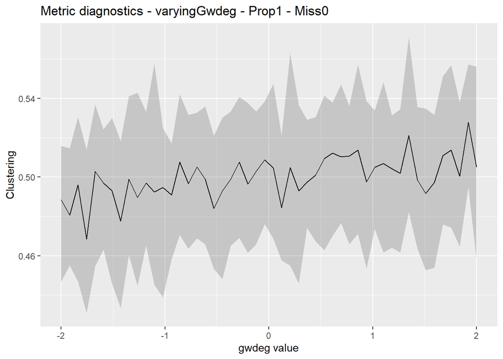

```r
# plotting the degraded metrics with the 'true' value
# and indexing which coefficients are used
# ... and what type of missingness it is...
# ... with indices for what network dataset and the proportion of missingness....

# initial code for making the plot data, turned into a function
# # extracting specific metrics
# uniqueMetrics = unique(names(unlist(degradedNetMetrics[[1]])))
#
# # initialise plot data
# metricPlotData = data.frame(metricName = NA, varyingParameter = NA, parameterValue = NA, quant0.05 = NA, median = NA, quant0.95 = NA)
#
# # additional list for metric ranges
# rawMetricList = list()
#
# # loop to choose different metrics in calculating the different quantiles
# for(chosenMetric in 1:length(uniqueMetrics)){
#
#   # a value for the row index based on the iteration of the loop
#   tempRowInd = seq(from = 1 + (length(degradedNetMetrics) * (chosenMetric - 1)), to = chosenMetric * length(degradedNetMetrics))
#
#   # fix this value for now, but this would depend on the model spec and which chosen para it is
#   chosenParaLabel = "gwdeg"
#   metricPlotData[tempRowInd,"varyingParameter"] = chosenParaLabel
#
#   # put in the metric name
#   metricPlotData[tempRowInd, "metricName"] = uniqueMetrics[chosenMetric]
#
#   # extract the chosen metrics from the nested list
#   rawMetricList[[chosenMetric]] = lapply(degradedNetMetrics, function(chosenParaVal){unlist(chosenParaVal)[names(unlist(chosenParaVal)) == uniqueMetrics[[chosenMetric]]]})
#
#   # fill in the quantiles
#   metricPlotData[tempRowInd, c("quant0.05", "median", "quant0.95")] = do.call(rbind, lapply(rawMetricList[[chosenMetric]], function(chosenParaVal){quantile(chosenParaVal, c(0.05, 0.5, 0.95))}))
#
#   # lastly, give the parameter values
#   metricPlotData[tempRowInd, "parameterValue"] = paraRange
# }

## Function to prep metric plot data
prepMetricPlot = function(degradedNetMetricList, chosenPara){

  ## prepMetricPlot(degradedNetMetricList, chosenPara) takes a list of metric calculated from degraded networks
  ## and a specified parameter name that controlled the degradation to subset them into a data frame to be used
  ## for plotting purposes.
  ##
  ## Input:
  ## - degradedNetMetricList: A list of (nested) network metrics calculated using the netMetrics function on
  ##                          a list of degraded networks. Missingness needs to be saved as 0 for values to calculable.
  ##
  ## - chosenPara: A string to describe which parameter is being varied in the degradation of the networks.
  ##
  ## Output:
  ## - A dataframe containing the metric names, which parameter is being varied and what its value is for the degradation,
  ##   and three quantiles (5, 50, and 95) to describe the range and median of the degraded metric.


  # extracting specific metrics
  uniqueMetrics = unique(names(unlist(degradedNetMetricList[[1]])))

  # initialise plot data
  metricPlotData = data.frame(metricName = NA, varyingParameter = NA, parameterValue = NA, quant0.05 = NA, median = NA, quant0.95 = NA)

  # additional list for metric ranges
  rawMetricList = list()

  # loop to choose different metrics in calculating the different quantiles
  for(chosenMetric in 1:length(uniqueMetrics)){

    # a value for the row index based on the iteration of the loop
    tempRowInd = seq(from = 1 + (length(degradedNetMetricList) * (chosenMetric - 1)), to = chosenMetric * length(degradedNetMetricList))

    # fix this value for now, but this would depend on the model spec and which chosen para it is
    chosenParaLabel = chosenPara
    metricPlotData[tempRowInd,"varyingParameter"] = chosenParaLabel

    # put in the metric name
    metricPlotData[tempRowInd, "metricName"] = uniqueMetrics[chosenMetric]

    # extract the chosen metrics from the nested list
    rawMetricList[[chosenMetric]] = lapply(degradedNetMetricList, function(chosenParaVal){unlist(chosenParaVal)[names(unlist(chosenParaVal)) == uniqueMetrics[[chosenMetric]]]})

    # fill in the quantiles
    metricPlotData[tempRowInd, c("quant0.05", "median", "quant0.95")] = do.call(rbind, lapply(rawMetricList[[chosenMetric]], function(chosenParaVal){quantile(chosenParaVal, c(0.05, 0.5, 0.95))}))

    # lastly, give the parameter values
    metricPlotData[tempRowInd, "parameterValue"] = paraRange
  }

  # return the plot data
  return(metricPlotData)
}

metricPlotData = prepMetricPlot(degradedNetMetricList = degradedNetMetrics, chosenPara = "gwdeg")

# unqiue metric names
uniqueMetrics = unique(names(unlist(degradedNetMetrics[[1]])))

## now that the data's right, it's just a matter of plotting-
metricPlotData %>%
  filter(metricName == "clustering") %>%
  ggplot(aes(x = parameterValue, y = median)) +
  geom_line() +
  geom_ribbon(aes(ymin = quant0.05, ymax = quant0.95), alpha = 0.2) +
  labs(title = "Metric diagnostics - varyingGwdeg - Prop1 - Miss0") +
  xlab("gwdeg value") +
  ylab("Clustering")
```

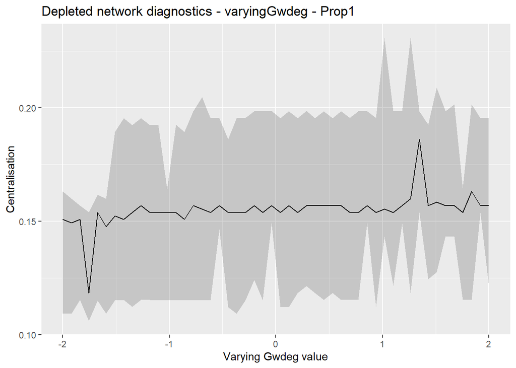

```r
# note: the chosen missingness will always be 0 because calculating metrics needs missingness to be 0, so take it off the plot title

## Turn this base plot code into a function-
missMetricPlot = function(data, chosenMetric, chosenPara, chosenProp){

  ## missMetricPlot(data, chosenMetric, chosenPara, chosenProp) is a very specialised plotting function that
  ## produces a caterpillar plot to compare parameter estimates for very specific data.
  ##
  ## Input:
  ## - data: A data frame containing the metric name, varying parameter, the varying parameter's value, and
  ##         5th, 50th, and 95th quantiles of the metric. Obtained from prepMetricPlot().
  ##
  ## - chosenPara: A string to describe which parameter is being varied in the degradation of the networks.
  ##
  ## - chosenProp: A single integer or float with three options representing the proportion of missingness.
  ##               Options are 1 = 10%, 3.5 = 35%, 6 = 60%.
  ##
  ## Output:
  ## - The output should be a line plot with a shaded area representing the 90% confidence interval of the metric.
  ##   Its labels should be adaptive to the chosen metric, (varying) parameter, and proportion of missingness.


  # requires ggplot2 and dplyr
  require(ggplot2)
  require(dplyr)

  # and plot
  data %>%
  filter(metricName == chosenMetric) %>%
  ggplot(aes(x = parameterValue, y = median)) +
  geom_line() +
  geom_ribbon(aes(ymin = quant0.05, ymax = quant0.95), alpha = 0.2) +
  labs(title = paste("Depleted network diagnostics - varying", chosenPara," - Prop", chosenProp, sep = "")) +
  xlab(paste("Varying", chosenPara, "value")) +
  ylab(paste(toupper(substr(chosenMetric, 1, 1)), substr(chosenMetric, 2, nchar(chosenMetric)), sep = ""))

}


# do this for all the unique metrics
missMetricPlot(data = metricPlotData, chosenMetric = uniqueMetrics[2], chosenPara = "Gwdeg", chosenProp = 1)
```

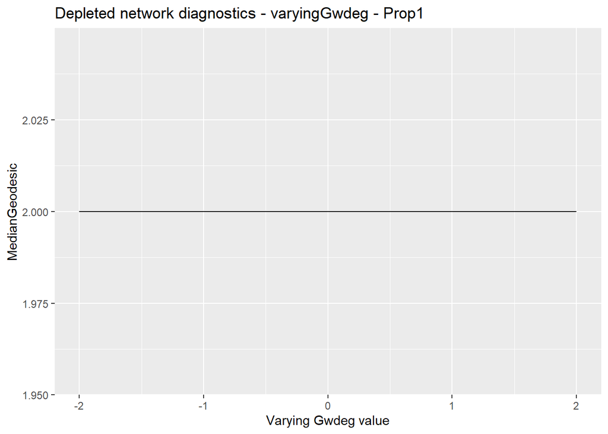

```r
missMetricPlot(data = metricPlotData, chosenMetric = uniqueMetrics[3], chosenPara = "Gwdeg", chosenProp = 1)
```

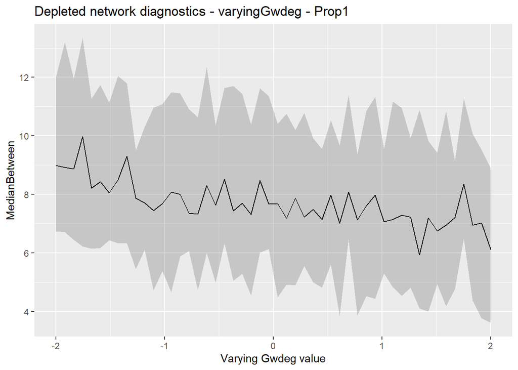

```r
missMetricPlot(data = metricPlotData, chosenMetric = uniqueMetrics[4], chosenPara = "Gwdeg", chosenProp = 1)
```

```r
### and now the mean value parameterisations
# a check to make sure it works
meanValPar(net = degradedNetList[[4]][[10]],
           model = "edges + gwdegree(decay = log(2), fixed = TRUE) + gwesp(decay = log(2), fixed = TRUE)")
```

```
##                         edges gwdeg.fixed.0.693147180559945
##                      85.00000                      52.16602
## gwesp.fixed.0.693147180559945
##                     129.68750
```

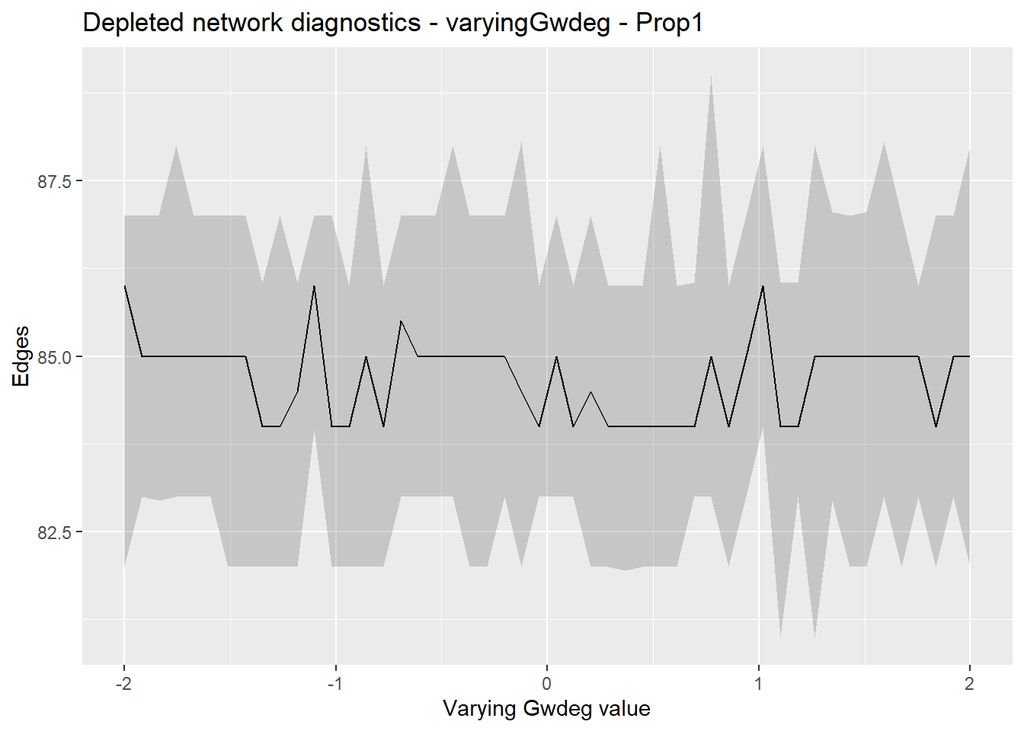

```r
# mass apply to lists
meanValParLists = lapply(degradedNetList, function(chosenParaVal){
  lapply(chosenParaVal, meanValPar, model = "edges + gwdegree(decay = log(2), fixed = TRUE) + gwesp(decay = log(2), fixed = TRUE)")
})

# unlist them to plot
meanValParUnlisted = lapply(meanValParLists, unlist)

### commented out section is for code that is largely identical to the function to prep plot data above
# # initialise plot data
# meanValPlotData = data.frame(parameterName = NA, varyingParameter = NA, parameterValue = NA, quant0.05 = NA, median = NA, quant0.95 = NA)
#
# # additional list for metric ranges
# rawMeanValList = list()
#
# # grab unique parameter names
# uniqueParaNames = unique(names(meanValParUnlisted[[1]]))
#
# # loop to grab the quantiles of each of these mean value parameterisation values for each parameter
# for(chosenParaName in 1:length(uniqueParaNames)){
#
#   # a value for the row index based on the iteration of the loop
#   tempRowInd = seq(from = 1 + (length(meanValParUnlisted) * (chosenParaName - 1)), to = chosenParaName * length(meanValParUnlisted))
#
#   # fix this value for now, but this would depend on the model spec and which chosen para it is
#   chosenParaLabel = "gwdeg"
#   meanValPlotData[tempRowInd,"varyingParameter"] = chosenParaLabel
#
#   # put in the metric name
#   meanValPlotData[tempRowInd, "parameterName"] = uniqueParaNames[chosenParaName]
#
#   # extract the chosen metrics from the nested list
#   rawMeanValList[[chosenParaName]] = lapply(meanValParLists, function(chosenParaVal){unlist(chosenParaVal)[names(unlist(chosenParaVal)) == uniqueParaNames[[chosenParaName]]]})
#
#   # fill in the quantiles
#   meanValPlotData[tempRowInd, c("quant0.05", "median", "quant0.95")] = do.call(rbind, lapply(rawMeanValList[[chosenParaName]], function(chosenParaVal){quantile(chosenParaVal, c(0.05, 0.5, 0.95))}))
#
#   # lastly, give the parameter values
#   meanValPlotData[tempRowInd, "parameterValue"] = paraRange
# }

## if I consider the mean value parametrisations as another metric, I don't need another chunk of code specifically for these
meanValPlotData = prepMetricPlot(degradedNetMetricList = meanValParUnlisted, chosenPara = "gwdeg")

# check all unique parameter names
uniqueParaNames = unique(names(meanValParUnlisted[[1]]))

# and check to make sure the plots work
missMetricPlot(data = meanValPlotData, chosenMetric = uniqueParaNames[1], chosenPara = "Gwdeg", chosenProp = 1)
```

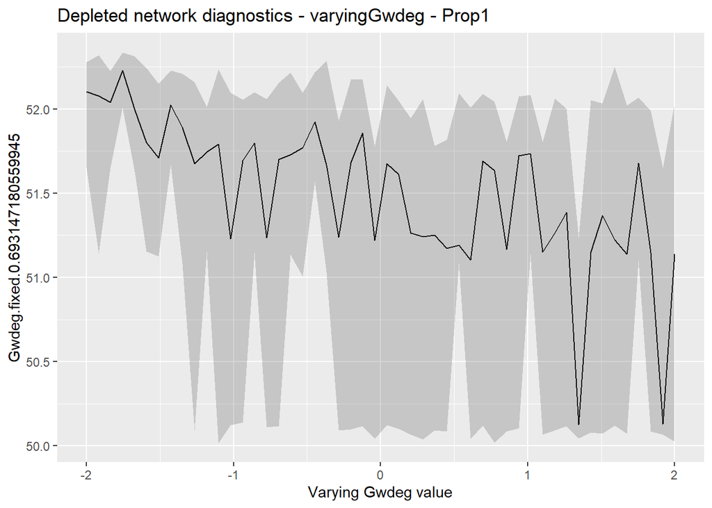

```r
missMetricPlot(data = meanValPlotData, chosenMetric = uniqueParaNames[2], chosenPara = "Gwdeg", chosenProp = 1)
```

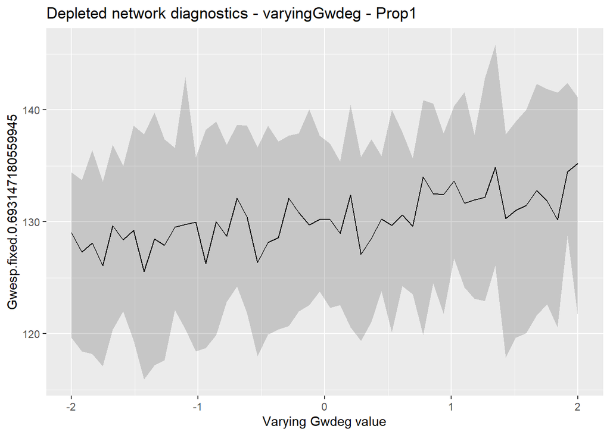

```r
missMetricPlot(data = meanValPlotData, chosenMetric = uniqueParaNames[3], chosenPara = "Gwdeg", chosenProp = 1)
```